# Análise de Expressão Diferencial

O trabalho apresentado foi desenvolvido em conjunto por Mariana Oliveira (PG52648), Rui Sousa (PG21019) e Samuel Baptista (PG49130), realizado no âmbito da Unidade Curricular de Extração de Conhecimento de Dados Biológicos do Mestrado em Bioinformática.

Este documento é a replicação da análise feita previamente em R, focando essencialmente no código e na análise dos resultados obtidos.

# Bibliotecas

O código seguinte instala e/ou importa as bibliotecas necessárias para o bom funcionamente do código subsequente.

```python
import os
import subprocess
import sys

def import_or_install(package, import_name=None):
    """
    Tenta importar um pacote. Se não for possível importá-lo, tenta instalar
    o pacote usando o pip e, em seguida, importá-lo novamente.

    Parâmetros:
        package (str): O nome do pacote a ser importado ou instalado.
        import_name (str): O nome do módulo a ser importado, se diferente do nome do pacote.

    Exemplo:
        >>> import_or_install('numpy')
        Tenta importar o pacote 'numpy'. Se não estiver disponível, tenta
        instalar usando o pip e, em seguida, importá-lo novamente.
    """
    import_name = import_name or package
    try:
        globals()[import_name] = __import__(import_name)
        print(f"Pacote {package} ({import_name}) encontrado.")
    except ImportError:
        print(f"Pacote {package} ({import_name}) não encontrado. Tentando instalar...")
        try:
            subprocess.check_call([sys.executable, "-m", "pip", "install", package])
            globals()[import_name] = __import__(import_name)
            print(f"Pacote {package} ({import_name}) instalado e importado com sucesso.")
        except subprocess.CalledProcessError as e:
            print(f"Falha ao instalar o pacote {package}. Erro: {e}")
        except ImportError:
            print(f"Pacote {package} instalado, mas falha ao importar.")

# Atualizar pip antes de tentar instalar os pacotes
try:
    subprocess.check_call([sys.executable, "-m", "pip", "install", "--upgrade", "pip"])
    print("pip atualizado com sucesso.")
except subprocess.CalledProcessError as e:
    print(f"Falha ao atualizar pip. Erro: {e}")

# Lista de pacotes a instalar com respectivos nomes de importação
pkgs = {
    'pandas': 'pandas',
    'seaborn': 'seaborn',
    'matplotlib': 'matplotlib',
    'scipy': 'scipy',
    'numpy': 'numpy',
    'scikit-learn': 'sklearn',   # scikit-learn é importado como sklearn
    'pydeseq2': 'pydeseq2',
    'gseapy': 'gseapy',
    'sanbomics': 'sanbomics',
    'fastcluster': 'fastcluster'
}

# Tentar instalar e importar cada pacote
for pkg, import_name in pkgs.items():
    import_or_install(pkg, import_name)

# Verificar se todos os pacotes foram importados corretamente
for pkg, import_name in pkgs.items():
    if import_name not in globals():
        print(f"Pacote {pkg} ({import_name}) não foi importado corretamente.")
    else:
        print(f"Pacote {pkg} ({import_name}) importado com sucesso.")
```

```
pip atualizado com sucesso.
Pacote pandas (pandas) encontrado.
Pacote seaborn (seaborn) encontrado.
Pacote matplotlib (matplotlib) encontrado.
Pacote scipy (scipy) encontrado.
Pacote numpy (numpy) encontrado.
Pacote scikit-learn (sklearn) encontrado.
Pacote pydeseq2 (pydeseq2) encontrado.
Pacote gseapy (gseapy) encontrado.
Pacote sanbomics (sanbomics) encontrado.
Pacote fastcluster (fastcluster) encontrado.
Pacote pandas (pandas) importado com sucesso.
Pacote seaborn (seaborn) importado com sucesso.
Pacote matplotlib (matplotlib) importado com sucesso.
Pacote scipy (scipy) importado com sucesso.
Pacote numpy (numpy) importado com sucesso.
Pacote scikit-learn (sklearn) importado com sucesso.
Pacote pydeseq2 (pydeseq2) importado com sucesso.
Pacote gseapy (gseapy) importado com sucesso.
Pacote sanbomics (sanbomics) importado com sucesso.
Pacote fastcluster (fastcluster) importado com sucesso.
```

# Upload dos Dados

Os dados para esta parte de python foram obtidos por conversão das variáveis em R. Usamos os packages TCGA BioLinks para transferir os dados necessários e depois estes foram exportados.

A lógica em R:

```
write_csv(seqdata, 'seqdata.csv') # Para excluir os rownames e manter os nomes do gene
write_csv(meta, 'meta.csv', rownames = FALSE) # Para manter o barcode
```

```python
print('A criar pasta para output')

if not os.path.exists('./output'):
    os.mkdir('./output')
```

```
A criar pasta para output
```

# Pré-processamento de dados

Abaixo é realizado o pré-processamento dos dados importados. É utilizada uma pipeline comum com a biblioteca `pandas`, sendo realizadas várias operações de modificação de índices, nomes de colunas e filtragem de dados. O resultado final é um *dataframe* com 248 colunas, correspondente às amostras com subtipo de adenocarcinoma do pulmão e 60660 linhas correspondentes a todos os genes analisados. Os passos seguintes consistirão na filtragem dos dados com base em CPM (*counts per million*).

```python
floc = './dataset/seqdata.csv'
print(f'A importar o dataframe na localização {floc}\n')
seqdata = pandas.read_csv('./dataset/seqdata.csv')
print('A renomear colunas e a definir genes como índice.\n')
seqdata = seqdata.rename(columns={'Unnamed: 0':'Genes'})
seqdata = seqdata.set_index('Genes')
print('Concluído!',
      'Dataframe seqdata com:',
      f'    - {seqdata.shape[1]} colunas',
      f'    - {len(seqdata)} linhas',
      sep= '\n'
      )
print('A mostrar head do dataframe\n',seqdata.head())
```

```
A importar o dataframe na localização ./dataset/seqdata.csv

A renomear colunas e a definir genes como índice.

Concluído!
Dataframe seqdata com:
    - 600 colunas
    - 60660 linhas
A mostrar head do dataframe
           TCGA-38-7271-01A-11R-2039-07  TCGA-55-7914-01A-11R-2170-07  \
Genes
TSPAN6                            1536                          2936
TNMD                                 0                             0
DPM1                               765                          1447
SCYL3                              510                           827
C1orf112                           172                           241

          TCGA-95-7043-01A-11R-1949-07  TCGA-73-4658-01A-01R-1755-07  \
Genes
TSPAN6                            1475                          3659
TNMD                                 0                           188
DPM1                              1275                           981
SCYL3                              373                           456
C1orf112                           172                           158

          TCGA-86-8076-01A-31R-2241-07  TCGA-55-7726-01A-11R-2170-07  \
Genes
TSPAN6                            3269                          1188
TNMD                                 0                             0
DPM1                              1540                          1564
SCYL3                             1171                           269
C1orf112                           318                           219

          TCGA-44-6147-01A-11R-A278-07  TCGA-50-5932-01A-11R-1755-07  \
Genes
TSPAN6                            2178                          4545
TNMD                                 4                             0
DPM1                              1430                          1557
SCYL3                             1139                          1185
C1orf112                           434                           322
```

[output cut: 35 more lines]

```
TSPAN6                            5948                          2272
TNMD                                 0                             0
DPM1                              1174                           851
SCYL3                              628                           565
C1orf112                           572                           199

          TCGA-55-6969-01A-11R-1949-07  TCGA-55-6969-11A-01R-1949-07
Genes
TSPAN6                            2233                           513
TNMD                                 0                             1
DPM1                              2803                           754
SCYL3                              940                           350
C1orf112                           647                            73

[5 rows x 600 columns]
```

# Metadados

## Carregamento dos metadados 1.0

```python
# Carregamento de metadados
floc = './dataset/meta.csv'
print(f'A importar o dataframe na localização {floc}\n')
meta = pandas.read_csv('./dataset/meta.csv')
print('A renomear colunas e a definir barcode como índice.\n')
meta = meta.set_index('barcode')
print('Concluído!',
      'Dataframe meta com:',
      f'    - {meta.shape[1]} colunas',
      f'    - {len(meta)} linhas',
      sep= '\n'
      )
print('A mostrar head do dataframe\n',meta.head())
```

```
A importar o dataframe na localização ./dataset/meta.csv

A renomear colunas e a definir barcode como índice.

Concluído!
Dataframe meta com:
    - 2 colunas
    - 600 linhas
A mostrar head do dataframe
                               gender           expr
barcode
TCGA-38-7271-01A-11R-2039-07  female            NaN
TCGA-55-7914-01A-11R-2170-07  female            TRU
TCGA-95-7043-01A-11R-1949-07  female  prox.-prolif.
TCGA-73-4658-01A-01R-1755-07  female   prox.-inflam
TCGA-86-8076-01A-31R-2241-07    male            NaN
```

### Verificação de valores omissos

```python
# Verifica a existência de dados omissos
print('A verificar a existência de dados omissos:', meta.isna().any(), sep='\n')
```

```
A verificar a existência de dados omissos:
gender    False
expr       True
dtype: bool
```

```python
# Remover NAs do expr. subtype
print('A remover dados omissos do dataframe de metadados.')
meta_clean = meta.dropna(how='any')

if len(meta_clean) == 248:
    print(f'data set de subtipo de expressão contém 248 valores como esperado, com tamanho {len(meta_clean)}')

print('Concluído!',
      'A mostrar head do dataframe tratado:',
      meta_clean.head(),
      sep='\n')
```

```
A remover dados omissos do dataframe de metadados.
data set de subtipo de expressão contém 248 valores como esperado, com tamanho 248
Concluído!
A mostrar head do dataframe tratado:
                              gender           expr
barcode
TCGA-55-7914-01A-11R-2170-07  female            TRU
TCGA-95-7043-01A-11R-1949-07  female  prox.-prolif.
TCGA-73-4658-01A-01R-1755-07  female   prox.-inflam
TCGA-55-7726-01A-11R-2170-07  female   prox.-inflam
TCGA-44-6147-01A-11R-A278-07  female            TRU
```

### Filtragem das colunas do dataframe seqdata de acordo com os metadados existentes

```python
# Filtrar seqdata com base no filtro
print('A reorganizar e filtrar dataframe seqdata com base nos índices dos metadados.')
seqdata_clean = seqdata[meta_clean.index] # Não é preciso validar pois as colunas já estão pelo nome
print('Concluído!')
```

```
A reorganizar e filtrar dataframe seqdata com base nos índices dos metadados.
Concluído!
```

## Carregamento dos metadados 2.0

Foi feita um segundo objeto com metadados relacionados com os hábitos de fumo e com o estado vital.

### Hábitos de fumo

```python
# Carregamento de hábitos de fumo
floc = './dataset/fumo.csv'
print(f'A importar o dataframe na localização {floc}\n')
smoke_status = pandas.read_csv('./dataset/fumo.csv')
print('A renomear colunas.\n')
smoke_status = smoke_status.rename(columns={
    'data.paper_Smoking.Status' : 'Smoke Habits',
    'data.years_smoked' : 'Years Smoked'})
print('A corrigir índice de acordo com o índice do dataframe de metadados.')
smoke_status.drop(columns=['Unnamed: 0', 'Years Smoked'], inplace=True)
smoke_status['barcode'] = meta.index

# Filtramos por Smoke Habits
print('A limpar dados:')
print('Removendo dados omissos.')
smoke_status.isna().any()
smoke_status_clean = smoke_status[(smoke_status['Smoke Habits'].notna()) & (smoke_status['Smoke Habits'] != '[Not Available]')]
print('A gerar dataset limpo')
smoke_status_clean = smoke_status_clean[['barcode', 'Smoke Habits']]
print('Concluído!',
      'Dataframe seqdata com:',
      f'    - {smoke_status_clean.shape[1]} colunas',
      f'    - {len(smoke_status_clean)} linhas',
      sep= '\n'
      )
print('A mostrar head do dataframe\n',smoke_status_clean.head())
```

```
A importar o dataframe na localização ./dataset/fumo.csv

A renomear colunas.

A corrigir índice de acordo com o índice do dataframe de metadados.
A limpar dados:
Removendo dados omissos.
A gerar dataset limpo
Concluído!
Dataframe seqdata com:
    - 2 colunas
    - 237 linhas
A mostrar head do dataframe
                         barcode                                 Smoke Habits
1  TCGA-55-7914-01A-11R-2170-07                               Current smoker
2  TCGA-95-7043-01A-11R-1949-07  Current reformed smoker for < or = 15 years
3  TCGA-73-4658-01A-01R-1755-07       Current reformed smoker for > 15 years
5  TCGA-55-7726-01A-11R-2170-07       Current reformed smoker for > 15 years
6  TCGA-44-6147-01A-11R-A278-07       Current reformed smoker for > 15 years
```

### Estado vital

```python
vital = pandas.read_csv('./dataset/vital.csv')

vital.rename(columns={'data.barcode' : 'barcode', 'data.vital_status' : 'Vital Status'}, inplace=True)

vital_vs_smoke = pandas.merge(
    smoke_status_clean,
    vital,
    on = 'barcode',
    how = 'inner'
)

vital_vs_smoke = vital_vs_smoke[['barcode', 'Smoke Habits', 'Vital Status']]
vital_vs_smoke['Smoke Habits'] = vital_vs_smoke['Smoke Habits'].replace(
    {'Current reformed smoker for > 15 years' : 'EX > 15 y',
    'Current reformed smoker for < or = 15 years' : 'EX <= 15 y',
    'Current smoker': 'Smokes',
    'Lifelong Non-smoker': 'Never smoked'
})
vital_vs_smoke
```

|  | barcode | Smoke Habits | Vital Status |
| --- | --- | --- | --- |
| 0 | TCGA-55-7914-01A-11R-2170-07 | Smokes | Dead |
| 1 | TCGA-95-7043-01A-11R-1949-07 | EX <= 15 y | Dead |
| 2 | TCGA-73-4658-01A-01R-1755-07 | EX > 15 y | Dead |
| 3 | TCGA-55-7726-01A-11R-2170-07 | EX > 15 y | Alive |
| 4 | TCGA-44-6147-01A-11R-A278-07 | EX > 15 y | Alive |
| ... | ... | ... | ... |
| 232 | TCGA-78-7153-01A-11R-2039-07 | EX <= 15 y | Alive |
| 233 | TCGA-38-4628-01A-01R-1206-07 | Never smoked | Dead |
| 234 | TCGA-86-7713-01A-11R-2066-07 | Never smoked | Alive |
| 235 | TCGA-44-2662-01B-02R-A277-07 | EX > 15 y | Alive |
| 236 | TCGA-53-7626-01A-12R-2066-07 | EX <= 15 y | Dead |

237 rows × 3 columns

### Filtragem das colunas do dataframe seqdata de acordo com os metadados existentes

```python
vital_vs_smoke2 = vital_vs_smoke.set_index('barcode')
vital_vs_smoke2.head()
```

| barcode | Smoke Habits | Vital Status |
| --- | --- | --- |
| TCGA-55-7914-01A-11R-2170-07 | Smokes | Dead |
| TCGA-95-7043-01A-11R-1949-07 | EX <= 15 y | Dead |
| TCGA-73-4658-01A-01R-1755-07 | EX > 15 y | Dead |
| TCGA-55-7726-01A-11R-2170-07 | EX > 15 y | Alive |
| TCGA-44-6147-01A-11R-A278-07 | EX > 15 y | Alive |

```python
# Filtrar seqdata com base no filtro
print('A reorganizar e filtrar dataframe seqdata com base nos índices dos metadados.')
seqdata_clean2 = seqdata[vital_vs_smoke2.index] # Não é preciso validar pois as colunas já estão pelo nome
print('Concluído!')
```

```
A reorganizar e filtrar dataframe seqdata com base nos índices dos metadados.
Concluído!
```

## Carregamento dos metadados 3.0

```python
stage = pandas.read_csv('./dataset/stage.csv')
stage.drop(columns=['Unnamed: 0'], inplace=True)

stage = stage.rename(columns={'data$paper_Tumor.stage' : 'Tumor Stage'})

stage['barcode'] = meta.index

print(f'encontrados {stage.iloc[:, 0].isna().sum()} valores omissos',
           'foi criada uma versão filtrada')

stage_clean = stage.dropna(how='any')
stage_clean[stage_clean['barcode'].isin(meta.index)]
stage_clean
```

```
encontrados 352 valores omissos foi criada uma versão filtrada
```

|  | Tumor Stage | barcode |
| --- | --- | --- |
| 1 | Stage IIA | TCGA-55-7914-01A-11R-2170-07 |
| 2 | Stage IA | TCGA-95-7043-01A-11R-1949-07 |
| 3 | Stage IB | TCGA-73-4658-01A-01R-1755-07 |
| 5 | Stage IA | TCGA-55-7726-01A-11R-2170-07 |
| 6 | Stage IA | TCGA-44-6147-01A-11R-A278-07 |
| ... | ... | ... |
| 588 | Stage IIA | TCGA-50-5055-01A-01R-1628-07 |
| 589 | Stage IIB | TCGA-38-4628-01A-01R-1206-07 |
| 591 | Stage IB | TCGA-86-7713-01A-11R-2066-07 |
| 593 | Stage IB | TCGA-44-2662-01B-02R-A277-07 |
| 595 | Stage IIA | TCGA-53-7626-01A-12R-2066-07 |

248 rows × 2 columns

## Conjuntos

No final, foram criados três conjuntos de metadados:

- Conjunto 1 (**meta**): género e tipo de expressão
- Conjunto 2 (**vital_vs_smoke**): hábitos de fumo e estado vital
- Conjunto 3 (**stage_clean**): estágio de tumor

# Análise inicial dos dados

À semelhança do trabalho realizado em R, são realizadas algumas análise estatísticas básicas com o intuito do correlacionar dados, nomeadamente:

- Distribuição de estado vital;
- Distribuição de hábitos de fumo;
- Correlação Hábitos de fumo / Estado vital;

Os resultados obtidos e os gráficos demonstrados são iguais aos demonstrados ao longo do relatório desenvolvido utilizando R, sendo a principal diferença o tipo de bibliotecas utilizadas.

## Estado vital

```
A preparar tabela de contingência para estado vital.
A preparar o gráfico.
```

```
Concluído, a exibir gráfico abaixo.
Plot gravado em ./output
```

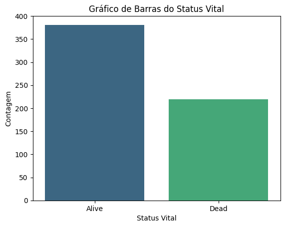

```python
print('A preparar tabela de contingência para estado vital.')
vital_status = vital['Vital Status'].value_counts()

# Plotting the bar plot
print('A preparar o gráfico.')
seaborn.barplot(x=vital_status.index, y=vital_status.values, palette="viridis")

matplotlib.pyplot.title("Gráfico de Barras do Status Vital")
matplotlib.pyplot.xlabel("Status Vital")
matplotlib.pyplot.ylabel("Contagem")


matplotlib.pyplot.savefig('./output/vital_status.pdf')
# Showing the plot
print('Concluído, a exibir gráfico abaixo.', 'Plot gravado em ./output\n',sep='\n')
matplotlib.pyplot.show()
```

## Hábitos de fumo

```
A preparar tabela de contingência para hábitos de fumo.
A preparar o gráfico.
```

```
Concluído, a exibir gráfico abaixo.
Plot gravado em ./output/
```

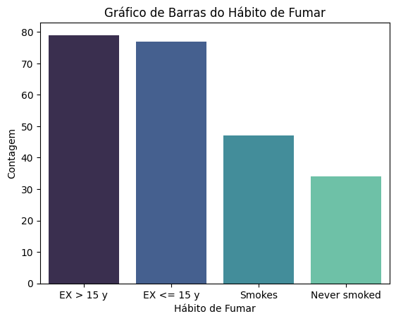

```python
# Adjusting smoke habit data
print('A preparar tabela de contingência para hábitos de fumo.')
smoke_habit = smoke_status_clean['Smoke Habits'].value_counts()
smoke_habit = smoke_habit.rename({
    'Current reformed smoker for > 15 years': 'EX > 15 y',
    'Current reformed smoker for < or = 15 years': 'EX <= 15 y',
    'Current smoker': 'Smokes',
    'Lifelong Non-smoker': 'Never smoked',
})

print('A preparar o gráfico.')
# Plotting smoke habit data
seaborn.barplot(x=smoke_habit.index, y=smoke_habit.values, palette="mako")

matplotlib.pyplot.title("Gráfico de Barras do Hábito de Fumar")
matplotlib.pyplot.xlabel("Hábito de Fumar")
matplotlib.pyplot.ylabel("Contagem")

matplotlib.pyplot.savefig('./output/smoke_habit.pdf')
# Showing the plot
print('Concluído, a exibir gráfico abaixo.', 'Plot gravado em ./output/\n',sep='\n')
matplotlib.pyplot.show()
```

## Hábitos de fumo vs Estado vital

```
Correlacionar hábitos de fumo com estado vital através de teste qui-quidrado.
A preparar tabela de contingência para alfa = 0.05
A realizar teste qui-quadrado.
Concluído, resultados abaixo:
Estatística de teste:2.954414510442226
Graus de liberdade:3
Valor de prova:0.3987070944866199
Para alfa = 0.05:
Não é plausível considerar correlação
A criar um gráfico para os resultados.
Concluído, a exibir gráfico abaixo.
Plot gravado em ./output/
```

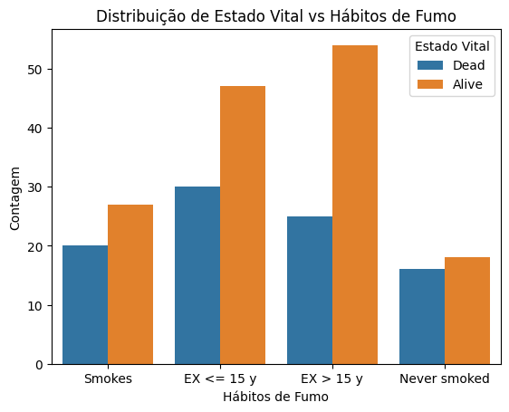

```python
print('Correlacionar hábitos de fumo com estado vital através de teste qui-quidrado.',
      'A preparar tabela de contingência para alfa = 0.05',
      sep='\n')
contingency_table = pandas.crosstab(vital_vs_smoke['Vital Status'], vital_vs_smoke['Smoke Habits'])
alpha = 0.05
print('A realizar teste qui-quadrado.')
chi2, p, dof, expected = scipy.stats.chi2_contingency(contingency_table)
print('Concluído, resultados abaixo:',
      f'Estatística de teste:{chi2}',
      f'Graus de liberdade:{dof}',
      f'Valor de prova:{p}',
      f'Para alfa = {0.05}:',
      sep = '\n')

# para 95% IC
if p < 0.05:
    print('É plausível considerar correlação')

else:
    print('Não é plausível considerar correlação')

print('A criar um gráfico para os resultados.')
seaborn.countplot(x='Smoke Habits', hue = 'Vital Status', data = vital_vs_smoke)
matplotlib.pyplot.title('Distribuição de Estado Vital vs Hábitos de Fumo')
matplotlib.pyplot.xlabel('Hábitos de Fumo')
matplotlib.pyplot.ylabel('Contagem')
matplotlib.pyplot.legend(title = 'Estado Vital')

matplotlib.pyplot.savefig('./output/vital_vs_smoke.pdf')
print('Concluído, a exibir gráfico abaixo.', 'Plot gravado em ./output/\n',sep='\n')
matplotlib.pyplot.show()
```

# Análise de Expressão Diferencial utilizando PyDESEQ2

Para a análise de expressão genética diferencial em Python utilizamos a biblioteca `PyDESEQ2`, uma adaptação da biblioteca R DESEQ2.

```python
# Pipeline
# https://pydeseq2.readthedocs.io/en/latest/auto_examples/plot_pandas_io_example.html
# https://pydeseq2.readthedocs.io/en/latest/auto_examples/plot_step_by_step.html
# Credits to mousepixels: https://github.com/mousepixels/sanbomics_scripts/blob/main/PyDeseq2_DE_tutorial.ipynb
# And PyDeSEQ2 documentation

import pickle
from pydeseq2.dds import DeseqDataSet
from pydeseq2.default_inference import DefaultInference
from pydeseq2.ds import DeseqStats
```

Os dados para análise diferencial de expressão foram transpostos para uma tabela de contagens, verificando a correspondência dos dados com os metadados, e filtrando genes com contagens totais superiores a 10.

```python
print('A preparar dados para DESEQ:,'
      ' - Transport tabela de counts para cada gene',
      sep='\n')
counts = seqdata_clean
counts_df = counts.T
print('A criar tabela de metadados e verificar se todos os dados correspondem corretamente.')
metadata = meta_clean[['expr']]
# Verificar se dados correspondem
if (counts_df.index == meta_clean.index).all():
    print('Dados correspondem corretamente, a filtrar dataset retendo genes com counts > 10')
    genes_to_keep = counts_df.columns[counts_df.sum(axis=0) >= 10]
    print('A converter em dataframe')
    counts_df = counts_df[genes_to_keep]
```

```
A preparar dados para DESEQ:, - Transport tabela de counts para cada gene
A criar tabela de metadados e verificar se todos os dados correspondem corretamente.
Dados correspondem corretamente, a filtrar dataset retendo genes com counts > 10
A converter em dataframe
```

```python
import pydeseq2

inference = pydeseq2.default_inference.DefaultInference(n_cpus=8)
print('A gerar objeto DeseqDataSet')
dds = pydeseq2.dds.DeseqDataSet(
    counts = counts_df,
    metadata = metadata,
    design_factors='expr',
    refit_cooks=True,
    inference = inference
)

if type(dds) == pydeseq2.dds.DeseqDataSet:
    print('Dataset criado, a correr operações DESEQ:')
    dds.deseq2()
```

```
A gerar objeto DeseqDataSet
Dataset criado, a correr operações DESEQ:
```

```
Fitting size factors...
... done in 2.28 seconds.

Fitting dispersions...
... done in 65.10 seconds.

Fitting dispersion trend curve...
... done in 5.28 seconds.

Fitting MAP dispersions...
... done in 71.52 seconds.

Fitting LFCs...
... done in 43.94 seconds.

Replacing 8916 outlier genes.

Fitting dispersions...
... done in 14.44 seconds.

Fitting MAP dispersions...
... done in 13.27 seconds.

Fitting LFCs...
... done in 10.05 seconds.
```

```python
# Guardar para acelerar o processo mais á frente com o load (estilo RDA/RDS)
# open("dds.pkl", "wb") as f:
#    pickle.dump(dds, f)

#
#with open('dds.pkl', 'rb') as f:
#    pickle.load(f)
```

## Testes de Wald

O resultado da análise consiste numa tabela com:

- os níveis médios da expressão genética;
- a taxa de sobre/sobexpressão sob a forma $log_{2}(\frac{Expressão na condição A}{Expressão na condição B}$);
- resultados do teste estatístico, nomeadamente os valores de prova;

```python
# Criação de um objeto DeseqStats usando o conjunto de dados DESeq fornecido (dds) e os parâmetros especificados
# alpha: nível de significância para o teste (padrão 0.05)
# cooks_filter: filtragem de distância de Cook para remover possíveis outliers
# independent_filter: filtragem independente para aumentar o poder, removendo genes com contagem baixa
# inference: especifica o tipo de inferência estatística a ser usada (por exemplo, 'paramétrica', 'não paramétrica')
print('A executar tratamento estatístico dos dados.')
stat_res = pydeseq2.ds.DeseqStats(dds, alpha=0.05, cooks_filter=True, independent_filter=True, inference=inference)

# Execução do teste de Wald para análise de expressão diferencial no conjunto de dados DESeq
# O teste de Wald é um teste paramétrico usado para determinar se há uma diferença significativa na expressão
# Ele calcula valores de p e log fold changes para cada gene no conjunto de dados
print('A executar testes de Wald.')
stat_res.run_wald_test()

# Recuperação dos resultados do teste de Wald como um DataFrame do pandas
# Este DataFrame contém os resultados da análise de expressão diferencial, incluindo:
# - log fold changes
# - valores de p
# - valores de p ajustados (corrigidos para testes múltiplos)
# - estatísticas adicionais e metadados para cada gene
print('Concluído, a exibir resultados:')
stat_res.summary()
```

```
A executar tratamento estatístico dos dados.
A executar testes de Wald.
```

```
Running Wald tests...
... done in 16.58 seconds.
```

```
Concluído, a exibir resultados:
Log2 fold change & Wald test p-value: expr prox.-inflam vs TRU
                    baseMean  log2FoldChange     lfcSE      stat  \
Genes
TSPAN6           3372.659142        0.055701  0.104359  0.533749
TNMD                7.405713        1.198674  0.465215  2.576601
DPM1             1505.153644        0.424534  0.086944  4.882840
SCYL3             778.112463       -0.171164  0.076256 -2.244583
C1orf112          373.207836        0.725551  0.097846  7.415237
...                      ...             ...       ...       ...
ENSG00000288667     1.368924        0.404061  0.983904  0.410671
ENSG00000288669     0.200104        0.859831  0.967010  0.889165
ENSG00000288670   251.434561       -0.166020  0.100246 -1.656119
ENSG00000288674     5.382479       -0.612823  0.136808 -4.479424
ENSG00000288675    13.979935       -0.184320  0.129677 -1.421377

                       pvalue          padj
Genes
TSPAN6           5.935155e-01  7.454922e-01
TNMD             9.977692e-03  3.704820e-02
DPM1             1.045686e-06  1.453276e-05
SCYL3            2.479493e-02  7.668913e-02
C1orf112         1.214076e-13  7.640707e-12
...                       ...           ...
ENSG00000288667  6.813137e-01  8.093612e-01
ENSG00000288669  3.739143e-01           NaN
ENSG00000288670  9.769780e-02  2.185077e-01
ENSG00000288674  7.484490e-06  8.083786e-05
ENSG00000288675  1.552072e-01  3.063888e-01

[52310 rows x 6 columns]
```

Em seguida filtramos os dados, definindo como filtro:

- valor de prova seja tal que seja plausível considerar que são diferencialmente expressos (para um intervalo de confiança de 95%);
- valor de $| log_{2}FC |$ superior a 2, indicativo de um nível de sobre/sobexpressão
- CPM superior a 20

```python
# Extrair o DataFrame dos resultados do objeto de resultados estatísticos
print('A isolar dataframe de resultados')
rdf = stat_res.results_df

# Imprimir o número inicial de genes presentes nos resultados DataFrame
# Fornece uma contagem do número total de linhas (genes) antes da filtragem
print('Genes inicialmente presentes -->', len(rdf))

# Aplicar critérios de filtragem para selecionar genes significativos:
# Valor de p ajustado (padj) < 0,05
# Valor absoluto de log2 fold change (|log2FoldChange|) > 2
# Expressão média de base (baseMean) > 20
significant = rdf[(rdf.padj < 0.05) & (abs(rdf.log2FoldChange) > 2) & (rdf.baseMean > 20)]

# Imprimir o número de genes que satisfazem os critérios de expressão diferencial
# Isto dá uma ideia do tamanho do subconjunto que satisfaz os limites especificados
print(f'Genes mais diferencialmente expressos (log2FoldChange > 2, CPM > 20, padj < 0.05 -->', len(significant))  # Expected to be > 695

# Ordenar os genes significativos pelo valor p ajustado (padj) por ordem ascendente
# Isto assegura que os genes mais significativos estão no topo do DataFrame
significant = significant.sort_values(by='padj')

# Mostrar os 100 genes principais com base no DataFrame ordenado
# Isto devolve as primeiras 100 linhas (genes) após a ordenação
significant_top_100 = significant.head(100)

# Imprimir os índices dos 100 genes mais diferencialmente expressos
# Isto fornece uma lista dos genes mais significativos com base nos critérios de filtragem e ordenação
#print('Lista dos 100 genes mais diferencialmente expressos:', *significant_top_100.index, sep='\n')
```

```
A isolar dataframe de resultados
Genes inicialmente presentes --> 52310
Genes mais diferencialmente expressos (log2FoldChange > 2, CPM > 20, padj < 0.05 --> 279
```

## Gráfico MA

```
A criar MA Plot .
MA Plot gravado em ./output/
```

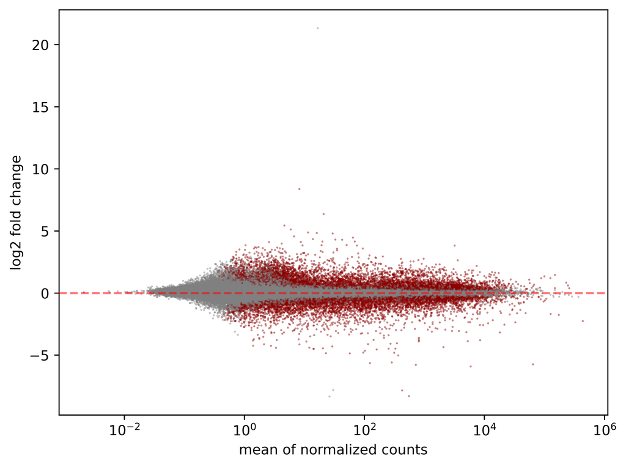

```python
#MA Plot
print('A criar MA Plot .')
matplotlib.pyplot.figure()
stat_res.plot_MA()
print('MA Plot gravado em ./output/')
matplotlib.pyplot.savefig('./output/MA_Plot.pdf')
```

## Heatmap

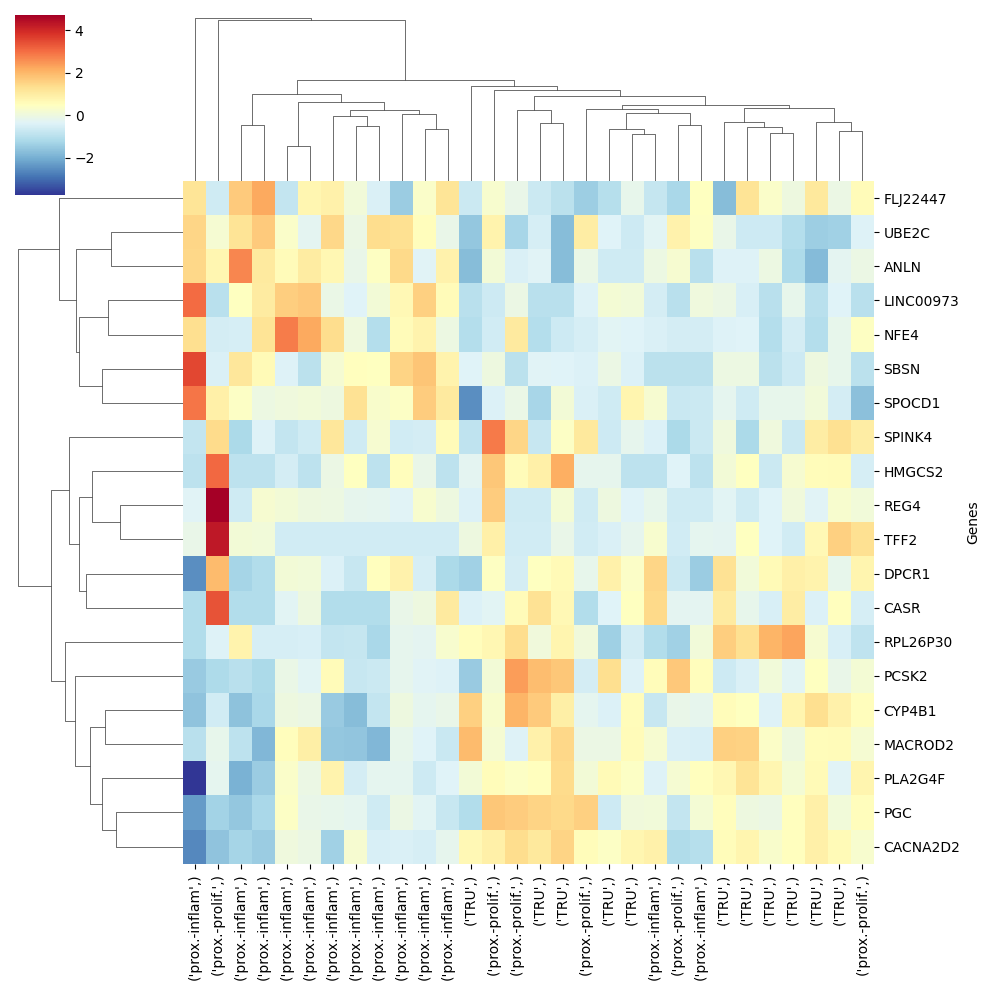

```python
# Isolar os 20 genes mais significativos
# Compute log-transformed counts and store them in a new layer 'logcounts'
# np.log1p(x) computes log(1 + x) which helps in managing zeros in the data
dds.layers['logcounts'] = numpy.log1p(dds.layers['normed_counts'])

# Display the 'logcounts' layer to verify the transformation
dds.layers['logcounts']

# Subset the DESeqDataSet to include only the first 50 rows and the significant indices
dds_sigs = dds[:30, significant.index[:20,]]

# Create a DataFrame for graphing with the log-transformed counts
# The DataFrame's index is the variable names (var_names)
# The DataFrame's columns are the observation names (obs_names)
grapher = pandas.DataFrame(
    dds_sigs.layers['logcounts'].T,
    index=dds_sigs.var_names,
    columns=dds_sigs.obs
)

# Plot a clustered heatmap of the data using seaborn's clustermap function
# z_score=0 standardizes the rows (genes) by subtracting the mean and dividing by the standard deviation
# cmap='RdYlBu_r' sets the color map to a diverging palette from red to yellow to blue, reversed
clustermap = seaborn.clustermap(grapher, z_score=0, cmap='RdYlBu_r')

clustermap.savefig('./output/heatmap.pdf')
```

A análise de um heatmap é uma etapa crucial na interpretação de dados de expressão genética ou qualquer outro tipo de matriz de dados multidimensionais. O heatmap visualiza a intensidade dos valores em uma matriz através de cores, permitindo a identificação de padrões e tendências subjacentes nos dados. Ao analisar um heatmap, é importante observar clusters de elementos que compartilham padrões semelhantes de expressão, representados por blocos de cores semelhantes. Esses clusters podem indicar grupos de genes ou amostras que têm perfis de expressão semelhantes, sugerindo associações biológicas ou correlações funcionais. Além disso, a análise dos gradientes de cor ao longo de linhas e colunas pode revelar padrões de expressão específicos em diferentes condições experimentais ou em diferentes grupos de amostras.

Os genes FLJ22447, UBE2C, ANLN e LINC00973 são genes que têm sido associados aos fatores de prognóstico de doentes com LUAD. Estes genes estão envolvidos na regulação do ciclo celular, na divisão celular e na proliferação celular, e pensa-se que a sua sobreexpressão contribui para a natureza agressiva dos tumores LUAD. Os genes NFE4, SBSN, SPOCD1, SPINK4 e HMGCS2 são genes cujos papeis na doença são menos bem compreendidos, podendo estar envolvidos no processo metastático e supressão tumoral. Estes genes podem estar envolvidos em processos como a diferenciação celular, o metabolismo e a resposta ao stress. Por outro lado, REG4, TFF2, DPCR1, CASR, RPL26P30, PCSK2, CYP4B1, MACROD2, PLA2G4F e PGC são genes associados a uma função pulmonar normal e pensa-se que são genes supressores de tumores. A sua desregulação pode contribuir para o desenvolvimento e progressão do LUAD. O CACNA2D2 é um gene que foi identificado como um potencial marcador de prognóstico no LUAD. A sua expressão está associada a uma melhor sobrevivência global e a uma sobrevivência sem recidivas em doentes com LUAD. Globalmente, estes genes representam um conjunto diversificado de intervenientes moleculares no LUAD, estando alguns associados a uma doença mais agressiva e outros a um melhor prognóstico.

Embora o quadro acima não permita fazer propriamente fazer uma distinção entre as diferentes condições (pois é possível ver que há alguns perfis semelhantes para condições diferentes) é possível perceber os perfis genéticos de cada amostra. Em todo o caso há um possível padrão e diferenças para as condições proximal inflamatory / proximal proliferative a TRU. É possível ainda ver que há efetivamente alteração nos perfis de expressão de genes reguladores críticos, desde genes supressores tumorais a genes relacionados com a agressividade e gravidade do tumor. Como próximos passos seria importante fazer uma análise mais detalhada para cada amostra e cada gene, constituindo estes potenciais alvos terapêuticos.

Fontes:

- [LINC03033 long intergenic non-protein coding RNA 3033 Homo sapiens (human) - Gene - NCBI](https://www.ncbi.nlm.nih.gov/gene?Db=gene&Cmd=DetailsSearch&Term=400221)
- [Expression of UBE2C in lung adenocarcinoma based on database analysis and its clinical significance](https://pubmed.ncbi.nlm.nih.gov/33051417/)
- [Comprehensive molecular profiling of lung adenocarcinoma - PMC](https://www.ncbi.nlm.nih.gov/pmc/articles/PMC4231481/)
- [Prognostic significance of ANLN in lung adenocarcinoma - PMC](https://www.ncbi.nlm.nih.gov/pmc/articles/PMC6036425/)
- [LINC00973 Induces Proliferation Arrest of Drug-Treated Cancer Cells by Preventing p21 Degradation - PMC](https://www.ncbi.nlm.nih.gov/pmc/articles/PMC7664178/)
- [Identification of candidate genes associated with triple negative breast cancer - PMC](https://www.ncbi.nlm.nih.gov/pmc/articles/PMC5620011/)
- [SBSN drives bladder cancer metastasis via EGFR/SRC/STAT3 signalling](https://pubmed.ncbi.nlm.nih.gov/35484216/)
- [SPOCD1 promotes the proliferation and metastasis of glioma cells by up-regulating PTX3 - PMC](https://www.ncbi.nlm.nih.gov/pmc/articles/PMC5934553/)
- [SPINKs in Tumors: Potential Therapeutic Targets - PMC](https://www.ncbi.nlm.nih.gov/pmc/articles/PMC8873584/)
- [3158 - Gene ResultHMGCS2 3-hydroxy-3-methylglutaryl-CoA synthase 2](https://www.ncbi.nlm.nih.gov/gene/3158)
- [REG4 is an indicator for KRAS mutant lung adenocarcinoma with TTF-1 low expression](https://pubmed.ncbi.nlm.nih.gov/31428934/)
- [Diagnostic utility of trefoil factor families for the early detection of lung cancer and their correlation with tissue expression - PMC](https://www.ncbi.nlm.nih.gov/pmc/articles/PMC9996639/)
- [Differences in the early stage gene expression profiles of lung adenocarcinoma and lung squamous cell carcinoma - PMC](https://www.ncbi.nlm.nih.gov/pmc/articles/PMC6865721/)
- [CYP4B1 is a prognostic biomarker and potential therapeutic target in lung adenocarcinoma - PMC](https://www.ncbi.nlm.nih.gov/pmc/articles/PMC7886130/)
- [MACROD2 Haploinsufficiency Impairs Catalytic Activity of PARP1 and Promotes Chromosome Instability and Growth of Intestinal Tumors](https://pubmed.ncbi.nlm.nih.gov/29880585/)
- [Integrated analysis of gene expression and DNA methylation datasets identified key genes and a 6-gene prognostic signature for primary lung adenocarcinoma - PMC](https://www.ncbi.nlm.nih.gov/pmc/articles/PMC8596225/)
- [Expression and Prognostic Significance of m6A-Related Genes in Lung Adenocarcinoma - PMC](https://www.ncbi.nlm.nih.gov/pmc/articles/PMC7049251/)
- [Prognostic value of immune-related genes in the tumor microenvironment of lung adenocarcinoma and lung squamous cell carcinoma - PMC](https://www.ncbi.nlm.nih.gov/pmc/articles/PMC7138544/)

# Análise de enriquecimento

Abaixo foi desenvolvida a análise de enriquecimento utilizando a biblioteca GSEApy.

```python
print('A mostrar a lista de bibliotecas de genes.')
gseapy.get_library_name()
```

```
A mostrar a lista de bibliotecas de genes.
```

[output not shown]

[output cut: 171 more lines]

[output not shown]

```python
lib = 'MSigDB_Oncogenic_Signatures'

print('A executar análise de enriquecimento e atribuição de rankings com base nos valores.',
      f'Irá ser utilizada a biblioteca {lib} por conter os oncogenes mais comuns.', sep='\n')
ranking = rdf[['stat']].dropna().sort_values('stat', ascending=False)

pre_res = gseapy.prerank(rnk = ranking,
                     gene_sets= ['MSigDB_Oncogenic_Signatures'],
                     seed = 6, permutation_num=100
                     )
print(
    'Concluído!',
    'A mostrar resultados de enriquecimento: ',
    '   - 3 genes com maior enrichment score (positivamente associados\n',
    pre_res.res2d[['Term','NES']].head(3),
    '   \n- 3 genes com menor enrichment score (negativamente associados)\n',
    pre_res.res2d[['Term','NES']].tail(3),
    sep='\n'
)
```

```
2024-06-02 17:35:12,234 [WARNING] Duplicated values found in preranked stats: 0.06% of genes
The order of those genes will be arbitrary, which may produce unexpected results.
```

```
A executar análise de enriquecimento e atribuição de rankings com base nos valores.
Irá ser utilizada a biblioteca MSigDB_Oncogenic_Signatures por conter os oncogenes mais comuns.
Concluído!
A mostrar resultados de enriquecimento:
   - 3 genes com maior enrichment score (positivamente associados

                                             Term       NES
0  MSigDB_Oncogenic_Signatures__CSR LATE UP.V1 UP  2.709744
1    MSigDB_Oncogenic_Signatures__VEGF A UP.V1 DN  2.662202
2   MSigDB_Oncogenic_Signatures__RB P107 DN.V1 UP  2.538424

- 3 genes com menor enrichment score (negativamente associados)

                                           Term       NES
185       MSigDB_Oncogenic_Signatures__EIF4E DN  0.989815
186   MSigDB_Oncogenic_Signatures__DCA UP.V1 DN  0.980617
187  MSigDB_Oncogenic_Signatures__GLI1 UP.V1 UP   0.86435
```

## Gráficos GSEA

Abaixo são construídos os diferentes GSEA plots para os top 3 / bottom 3 genes.

Os GSEA plots, ou gráficos de análise de enriquecimento de conjuntos de genes, são uma representação visual essencial na interpretação dos resultados da análise de enriquecimento GSEA. Esses gráficos exibem a distribuição acumulada de genes dentro de conjuntos funcionais pré-definidos ao longo de uma lista ordenada de genes, geralmente classificados por sua relevância em uma comparação de condições experimentais. Iremos analisar e identificar picos ou vales significativos na curva de enriquecimento, indicando conjuntos de genes que estão sobre-representados ou sub-representados para as condições analisadas.

```
A mostrar plot para os termos: 0 1 2 187 186 185 (Top 3 / Bottom 3)
A gravar plot para MSigDB_Oncogenic_Signatures__CSR LATE UP.V1 UP
A gravar plot para MSigDB_Oncogenic_Signatures__VEGF A UP.V1 DN
A gravar plot para MSigDB_Oncogenic_Signatures__RB P107 DN.V1 UP
A gravar plot para MSigDB_Oncogenic_Signatures__GLI1 UP.V1 UP
A gravar plot para MSigDB_Oncogenic_Signatures__DCA UP.V1 DN
A gravar plot para MSigDB_Oncogenic_Signatures__EIF4E DN
```

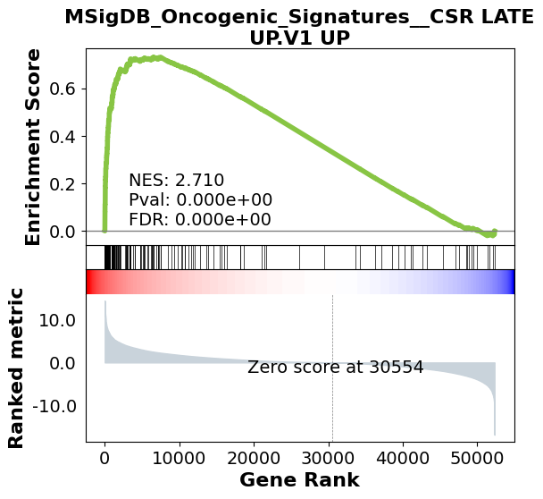

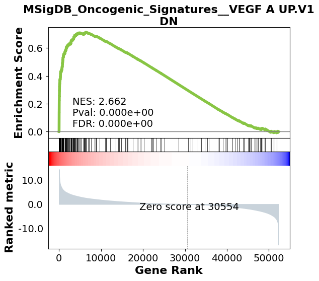

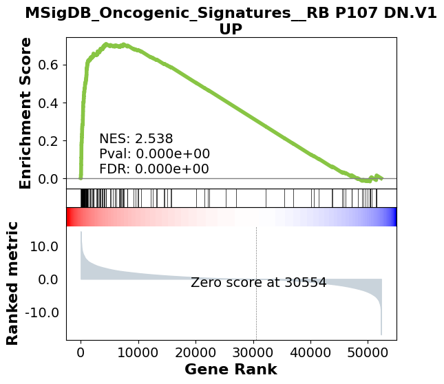

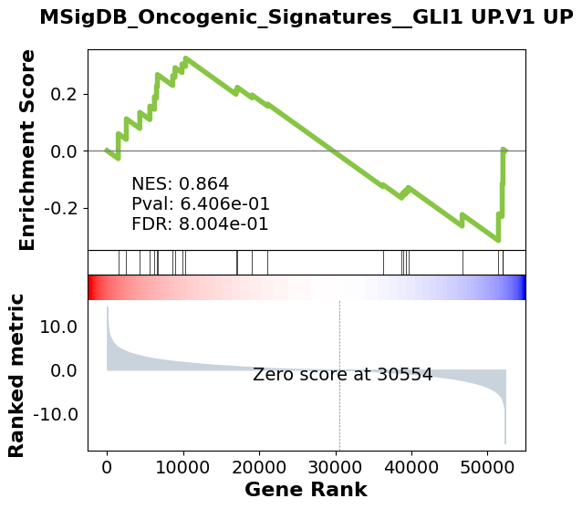

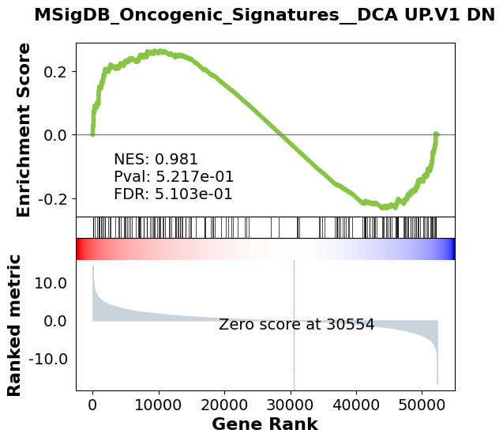

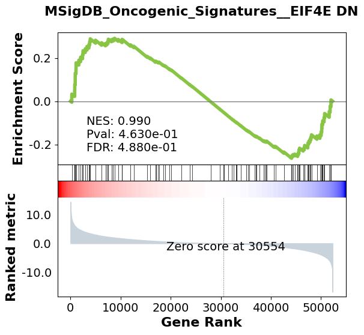

```python
terms = pre_res.res2d.Term
top_bottom_3 = [0,1,2,len(terms) - 1, len(terms) - 2, len(terms) - 3]
print(f'A mostrar plot para os termos:',*top_bottom_3, '(Top 3 / Bottom 3)')
i = 0
import os
for term in top_bottom_3:
    if not os.path.exists('./output/gsea_plots'):
        os.makedirs('./output/gsea_plots')
    gseapy.gseaplot(rank_metric=pre_res.ranking, term=terms[term], **pre_res.results[terms[term]])
    print(f'A gravar plot para {terms[term]}')
    gseapy.gseaplot(rank_metric=pre_res.ranking, term=terms[term], ofname=f'./output/gsea_plots/{terms[term]}.pdf', **pre_res.results[terms[term]])
    i += 1
```

Fontes:

- [How to interpret GSEA results and plot](https://www.youtube.com/watch?v=Yi4d7JIlAsM)
- [Identification of a novel intermittent hypoxia-related prognostic lncRNA signature and the ceRNA of lncRNA GSEC/miR-873-3p/EGLN3 regulatory axis in lung adenocarcinoma](https://www.ncbi.nlm.nih.gov/pmc/articles/PMC10573295/)
- [Increased VEGF-A in solid type of lung adenocarcinoma reduces the patients’ survival](https://www.nature.com/articles/s41598-020-79907-6)
- [GLI1-Amplifications Expands the Spectrum of Soft Tissue Neoplasms Defined by GLI1 Gene Fusions](https://www.ncbi.nlm.nih.gov/pmc/articles/PMC6821565/)
- [Human Gene Set: DCA_UP.V1_DN](https://www.gsea-msigdb.org/gsea/msigdb/cards/DCA_UP.V1_DN)
- [Human Gene Set: RAPA_EARLY_UP.V1_UP](https://www.gsea-msigdb.org/gsea/msigdb/cards/RAPA_EARLY_UP.V1_UP)

## Gráficos volcano

Abaixo é gerado o volcano plot para os resultados.

Os Volcano plots são uma ferramenta gráfica valiosa e frequentemente utilizada na análise de enriquecimento de conjuntos de genes (GSEA), proporcionando uma visualização eficaz das diferenças estatisticamente significativas na expressão genéticas entre duas condições experimentais. Esses gráficos apresentam a relação entre a significância estatística (usualmente expressa como -log10 do valor-p) e o tamanho do efeito (geralmente representado como o log2 da fold change) para cada gene ou conjunto de genes. Na análise de enriquecimento GSEA, os Volcano plots podem ser usados para identificar conjuntos de genes que estão significativamente enriquecidos ou depletados em uma condição experimental em comparação com uma condição de controle. Pontos localizados na região superior do gráfico, com valores-p muito baixos e fold changes grandes, indicam genes altamente diferencialmente expressos e potencialmente relevantes biologicamente. A interpretação dos Volcano plots no contexto da GSEA também envolve a avaliação da distribuição dos pontos e a presença de agrupamentos ou padrões, o que pode indicar a presença de conjuntos de genes coordenadamente regulados e associados a processos biológicos específicos. Em suma, os Volcano plots são uma ferramenta visual essencial na análise de enriquecimento GSEA, permitindo uma rápida identificação e interpretação dos genes mais significativamente alterados entre as condições experimentais estudadas.

```
A criar volcano plot
```

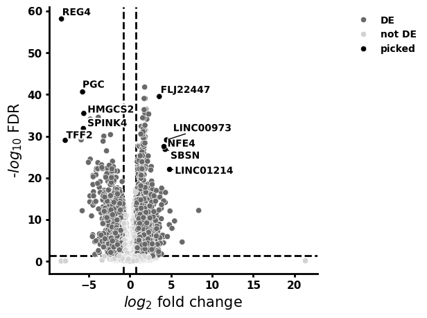

```
Concluído, a exibir plot. Plot gravado em ./output/
```

```python
from sanbomics import plots
print('A criar volcano plot')
rdf_copy = rdf.copy()
rdf_copy['Symbol'] = rdf_copy.index
matplotlib.pyplot.figure()
volc = sanbomics.plots.volcano(rdf_copy, symbol='Symbol')
print('Concluído, a exibir plot. Plot gravado em ./output/')
matplotlib.pyplot.savefig('./output/volcano_plot.pdf')
matplotlib.pyplot.show()
```

https://www.youtube.com/watch?v=7aWAdw2jhj0

# Clustering

Abaixo realizamos o clustering com o objetivo de organizar genes com base nas suas caraterísticas partilhadas. Iremos utilizar o clustering com distância de Manhatan dada a sua ampla utilização.

O clustering é uma técnica essencial em análise de dados, que organiza objetos similares em grupos distintos, conhecidos como clusters, com base em características compartilhadas. A distância de Manhattan, uma medida de dissimilaridade amplamente utilizada, é comumente empregada nesse contexto. A distância de Manhattan calcula a soma das diferenças absolutas entre as coordenadas de dois pontos em um espaço multidimensional. Essa abordagem, fundamental em diversas disciplinas como biologia, bioinformática e ciência da computação, permite identificar padrões intrínsecos nos dados. Os clusters resultantes destacam grupos de objetos que são mais similares internamente do que em relação a objetos em clusters diferentes. Métodos de clustering, como k-means, hierarchical clustering e DBSCAN, são aplicados de acordo com a natureza e a estrutura dos dados. Em resumo, o clustering, utilizando a distância de Manhattan como métrica, é uma ferramenta poderosa para revelar estruturas e relações complexas em conjuntos de dados multidimensionais, oferecendo insights valiosos para análise e interpretação de dados.

```
A preparar dados para clustering: escalar, estimar distância, clusterizar.
A exibir dendrograma. Dendrograma gravado em ./output/
```

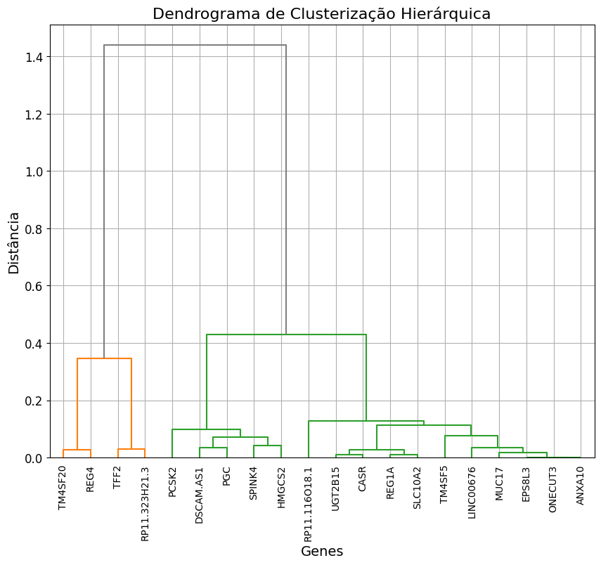

```python
print('A preparar dados para clustering: escalar, estimar distância, clusterizar.')

# Assume 'rdf' is a DataFrame with a 'log2FoldChange' column
res_ord = rdf.sort_values(by='log2FoldChange').log2FoldChange.to_frame(name='log2FoldChange').head(20)

# Scaling the selected data
scaled = sklearn.preprocessing.scale(res_ord)

# Performing hierarchical/agglomerative clustering
Z = scipy.cluster.hierarchy.linkage(scaled, metric='cityblock')

# Create a figure
matplotlib.pyplot.figure(figsize=(10, 8))

# Plot the dendrogram
dendro = scipy.cluster.hierarchy.dendrogram(
    Z,
    labels=list(res_ord.index),
    leaf_rotation=90,
    leaf_font_size=10,
    color_threshold=0.7 * max(Z[:, 2]),  # Set a color threshold for better visual separation
    above_threshold_color='gray'  # Color for clusters above the threshold
)

# Add title and labels
matplotlib.pyplot.title("Dendrograma de Clusterização Hierárquica", fontsize=16)
matplotlib.pyplot.xlabel("Genes", fontsize=14)
matplotlib.pyplot.ylabel("Distância", fontsize=14)

# Customize the font and layout
matplotlib.pyplot.xticks(fontsize=10)
matplotlib.pyplot.yticks(fontsize=12)
matplotlib.pyplot.grid(True)

# Save the dendrogram plot to a PDF file
matplotlib.pyplot.savefig('./output/dendrograma.pdf', bbox_inches='tight')

# Show the plot
print('A exibir dendrograma. Dendrograma gravado em ./output/')
matplotlib.pyplot.show()
```

Acima é representado o dendrograma gerado para os resultados do clustering, refletindo a estrutura hierárquica dos clusters. É possível identificar dois grandes grupos. O grupo à esquerda parece consistir de genes tipicamente relacionados com fatores associados ao tecido tumoral, como codificação de proteínas transmembranas, patogenicidade, etc. O grupo à direita aparenta estar relacionado com fatores de agressividade do tumor como tem vindo a ser discutido ao longo desta análise. Estes genes poderão constituir biomarcadores ou alvos terapêuticos interessantes, estando já identificados na literatura, corroborando os resultados desta análise.

- [Identification of potential diagnostic and prognostic biomarkers for LUAD based on TCGA and GEO databases](https://portlandpress.com/bioscirep/article/41/6/BSR20204370/228708/Identification-of-potential-diagnostic-and)

# Redução de dimensionalidade

```python
seqdata_clean_transposed = seqdata_clean.transpose()
seqdata_clean_transposed.shape
```

```
(248, 60660)
```

```python
seqdata_clean_transposed2 = seqdata_clean2.transpose()
seqdata_clean_transposed2.shape
```

```
(237, 60660)
```

## Multidimensional Scaling (MDS)

O Multidimensional Scaling (MDS) é uma técnica de análise de dados que permite visualizar a estrutura de dados multidimensionais num espaço de menor dimensão, geralmente 2D ou 3D. Isso é útil para explorar padrões, agrupamentos e relações complexas que podem estar presentes em conjuntos de dados com muitas variáveis.

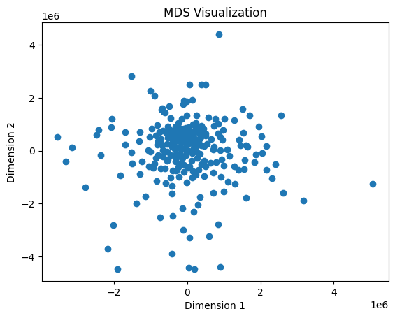

```python
from sklearn.manifold import MDS

# Specify the desired number of dimensions (e.g., 2 for visualization)
mds = MDS(n_components=2)

# Transform the data into the lower-dimensional space
data_r = mds.fit_transform(seqdata_clean_transposed)

import matplotlib.pyplot as plt

plt.scatter(data_r[:, 0], data_r[:, 1])  # Assuming 2D embedding
plt.xlabel("Dimension 1")
plt.ylabel("Dimension 2")
plt.title("MDS Visualization")
plt.show()
```

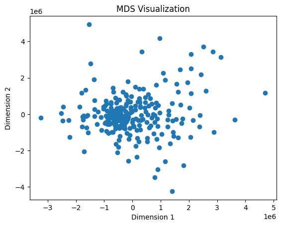

```python
from sklearn.manifold import MDS

# Specify the desired number of dimensions (e.g., 2 for visualization)
mds = MDS(n_components=2)

# Transform the data into the lower-dimensional space
data_r2 = mds.fit_transform(seqdata_clean_transposed2)

import matplotlib.pyplot as plt

plt.scatter(data_r2[:, 0], data_r2[:, 1])  # Assuming 2D embedding
plt.xlabel("Dimension 1")
plt.ylabel("Dimension 2")
plt.title("MDS Visualization")
plt.show()
```

## Principal Component Analysis (PCA)

A Análise de Componentes Principais (PCA) é uma técnica estatística usada para simplificar conjuntos de dados complexos, reduzindo a sua dimensionalidade. O PCA condensa um grande conjunto de variáveis num conjunto menor de recursos que capturam a maioria das informações importantes nos dados originais.

```python
from sklearn.decomposition import PCA
pca = PCA(n_components=15)
X_r = pca.fit(seqdata_clean_transposed).transform(seqdata_clean_transposed)
```

```python
print(pca.explained_variance_ratio_)
pca.explained_variance_ratio_.sum()
```

```
[0.26513986 0.15785643 0.10824162 0.06929256 0.05377627 0.04736253
 0.03461738 0.02607935 0.02362947 0.01892658 0.01503842 0.01322711
 0.01163408 0.01082671 0.0091935 ]
```

```
0.8648418797424687
```

```python
from sklearn.decomposition import PCA
pca2 = PCA(n_components=15)
X_r2 = pca2.fit(seqdata_clean_transposed2).transform(seqdata_clean_transposed2)
```

```python
print(pca2.explained_variance_ratio_)
pca2.explained_variance_ratio_.sum()
```

```
[0.26475782 0.15830363 0.10563574 0.07012952 0.05445919 0.04768041
 0.03446939 0.02648191 0.02367534 0.01918638 0.01528031 0.01338941
 0.01183852 0.0107995  0.00935132]
```

```
0.8654383857875823
```

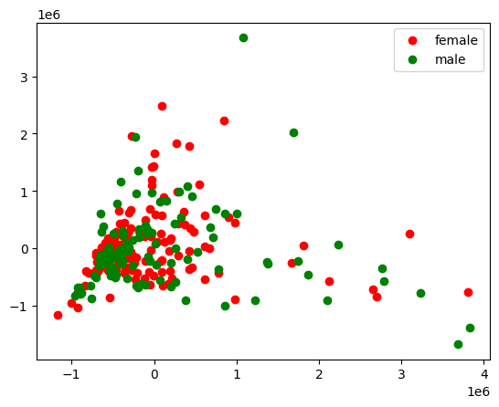

```python
%matplotlib inline
import matplotlib.pyplot as plt

meta_var = meta_clean.loc[:,"gender"]
meta_values = meta_var.unique()

plt.figure()
for c, name in zip("rgby", meta_values):
    plt.scatter(X_r[meta_var == name, 0], X_r[meta_var == name, 1], c=c, label=name)
plt.legend()
plt.show()
```

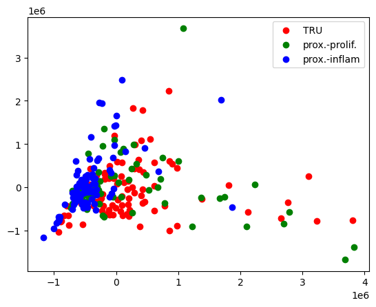

```python
%matplotlib inline
import matplotlib.pyplot as plt

meta_var = meta_clean.loc[:,"expr"]
meta_values = meta_var.unique()

plt.figure()
for c, name in zip("rgby", meta_values):
    plt.scatter(X_r[meta_var == name, 0], X_r[meta_var == name, 1], c=c, label=name)
plt.legend()
plt.show()
```

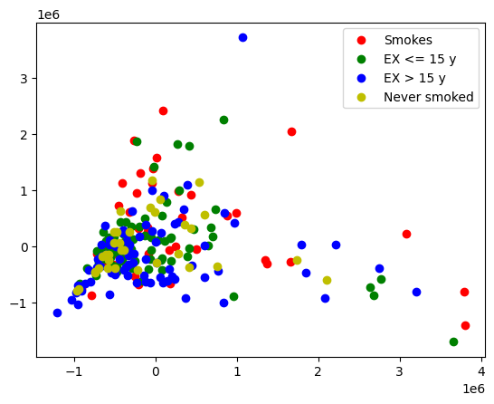

```python
%matplotlib inline
import matplotlib.pyplot as plt

meta_var = vital_vs_smoke2.loc[:,"Smoke Habits"]
meta_values = meta_var.unique()

plt.figure()
for c, name in zip("rgby", meta_values):
    plt.scatter(X_r2[meta_var == name, 0], X_r2[meta_var == name, 1], c=c, label=name)
plt.legend()
plt.show()
```

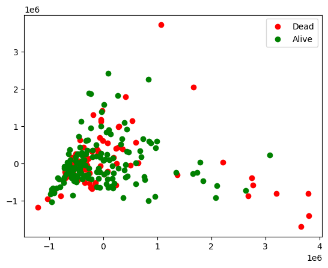

```python
%matplotlib inline
import matplotlib.pyplot as plt

meta_var = vital_vs_smoke2.loc[:,"Vital Status"]
meta_values = meta_var.unique()

plt.figure()
for c, name in zip("rgby", meta_values):
    plt.scatter(X_r2[meta_var == name, 0], X_r2[meta_var == name, 1], c=c, label=name)
plt.legend()
plt.show()
```

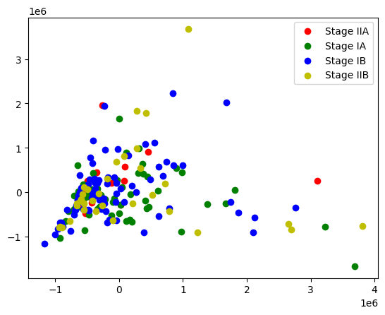

```python
%matplotlib inline
import matplotlib.pyplot as plt

meta_var = stage_clean.loc[:,"Tumor Stage"]
meta_values = meta_var.unique()

plt.figure()
for c, name in zip("rgby", meta_values):
    plt.scatter(X_r[meta_var == name, 0], X_r[meta_var == name, 1], c=c, label=name)
plt.legend()
plt.show()
```

Analisando os gráficos de PCA, em nenhum deles é possível inferir diferentes agrupamentos das diferentes classes de dados, portanto, o PCA não nos permite diferenciar as diferentes classes, pelo que os dados provavelmente não são suficientemente distintos para serem diferenciados em agrupamentos. À semelhança dos resultados obtidos na parte do R, isto pode indicar que as variáveis individuais se comportam de maneira diferente em relação à variação total dos dados.

Assim, isto indica que nas futuras etapas de treino dos modelos de machine learning, os modelos poderão apresentar dificuldade em classificar os dados.

## K-Means

O Clustering K-Means é um algoritmo de aprendizagem máquina não supervisionado que agrupa pontos de dados não rotulados num número predefinido de clusters. Ao contrário da aprendizagem supervisionada, onde os dados têm rótulos pré-atribuídos, o k-means ajuda a descobrir estruturas inerentes aos dados.

```
[12263131.116274707, 11013762.057586212, 10663689.614262588, 10305598.05878377, 10170473.243275613, 10036239.349990748, 9747456.895211315, 9596635.866691962, 9485731.307646025]
```

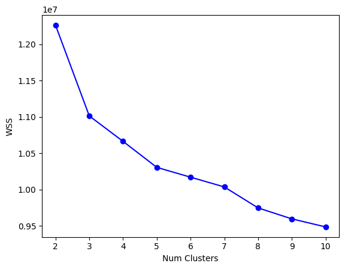

```python
from sklearn.cluster import KMeans

from sklearn import preprocessing
data_sc = preprocessing.scale(seqdata_clean_transposed) # pré-processamento dos dados (padronização dos dados, onde são centrados em torno da média e escalados para terem variância unitária)

# cálculo do Elbow Method:
ofs = [] # lista para armazenar a inércia de cada modelo de K-means

for k in range(2, 11): # iteração sobre um número de clusters variando de 2 a 10
    kmeans = KMeans(n_clusters=k, n_init = 10) # O parâmetro 'n_init' é definido como 10, o que significa que o algoritmo tentará 10 inicializações e selecionará a melhor baseada no critério interno do K-means
    kmeans.fit(data_sc) # para cada valor de k, o algoritmo K-means é aplicado aos dados padronizados ('data_sc')
    ofs.append(kmeans.inertia_) # armazenamento da inércia de cada modelo de K-means

print(ofs) # imprimir a lista que contém as inércias para cada número de clusters
# imprimir um gráfico onde o eixo x representa o número de clusters (k) e o eixo y representa a soma dos quadrados dentro do cluster (Within-Cluster Sum of Squares - WSS)
plt.plot(range(2, 11), ofs, 'b-o')
plt.xlabel('Num Clusters')
plt.ylabel('WSS')
plt.show()
```

```python
kmeans = KMeans(n_clusters=3, n_init = 10) # aplicação do algoritmo K-means aos dados padronizados ('data_sc')
res_kmeans = kmeans.fit(data_sc).predict(data_sc) # o método fit ajusta o modelo aos dados e o predict atribui a cada amostra o rótulo do cluster ao qual ela foi atribuída

# tabela de Contingência (cross-tabulation):
pandas.crosstab(meta_clean.loc[:,"expr"], res_kmeans) # criação de uma tabela de contingência (ou tabela de frequência cruzada)
# esta tabela mostra a contagem de amostras de tecido normal e tumoral para cada um dos clusters obtidos pelo K-means
```

| col_0 expr | 0 | 1 | 2 |
| --- | --- | --- | --- |
| TRU | 60 | 33 | 4 |
| prox.-inflam | 58 | 26 | 4 |
| prox.-prolif. | 41 | 22 | 0 |

```python
kmeans = KMeans(n_clusters=3, n_init = 10) # aplicação do algoritmo K-means aos dados padronizados ('data_sc')
res_kmeans = kmeans.fit(data_sc).predict(data_sc) # o método fit ajusta o modelo aos dados e o predict atribui a cada amostra o rótulo do cluster ao qual ela foi atribuída

# tabela de Contingência (cross-tabulation):
pandas.crosstab(stage_clean.loc[:,"Tumor Stage"], res_kmeans) # criação de uma tabela de contingência (ou tabela de frequência cruzada)
# esta tabela mostra a contagem de amostras de tecido normal e tumoral para cada um dos clusters obtidos pelo K-means
```

| col_0 Tumor Stage | 0 | 1 | 2 |
| --- | --- | --- | --- |
| Stage I | 1 | 1 | 0 |
| Stage IA | 38 | 12 | 2 |
| Stage IB | 42 | 33 | 5 |
| Stage IIA | 11 | 7 | 0 |
| Stage IIB | 22 | 11 | 1 |
| Stage IIIA | 26 | 12 | 0 |
| Stage IIIB | 6 | 3 | 0 |
| Stage IV | 7 | 2 | 0 |
| [Not Available] | 6 | 0 | 0 |

```
[12263131.116274707, 11013762.057586212, 10548709.85333648, 10199125.139793163, 10116932.382403532, 10000322.465182858, 9720996.880565695, 9603096.324304968, 9474651.078720018]
```

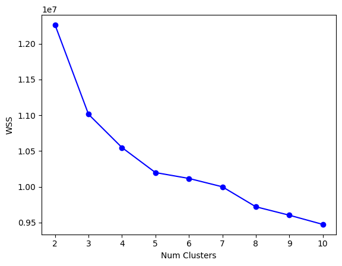

```python
from sklearn.cluster import KMeans

from sklearn import preprocessing
data_sc2 = preprocessing.scale(seqdata_clean_transposed2) # pré-processamento dos dados (padronização dos dados, onde são centrados em torno da média e escalados para terem variância unitária)

# cálculo do Elbow Method:
ofs = [] # lista para armazenar a inércia de cada modelo de K-means

for k in range(2, 11): # iteração sobre um número de clusters variando de 2 a 10
    kmeans = KMeans(n_clusters=k, n_init = 10) # O parâmetro 'n_init' é definido como 10, o que significa que o algoritmo tentará 10 inicializações e selecionará a melhor baseada no critério interno do K-means
    kmeans.fit(data_sc) # para cada valor de k, o algoritmo K-means é aplicado aos dados padronizados ('data_sc')
    ofs.append(kmeans.inertia_) # armazenamento da inércia de cada modelo de K-means

print(ofs) # imprimir a lista que contém as inércias para cada número de clusters
# imprimir um gráfico onde o eixo x representa o número de clusters (k) e o eixo y representa a soma dos quadrados dentro do cluster (Within-Cluster Sum of Squares - WSS)
plt.plot(range(2, 11), ofs, 'b-o')
plt.xlabel('Num Clusters')
plt.ylabel('WSS')
plt.show()
```

```python
kmeans = KMeans(n_clusters=3, n_init = 10) # aplicação do algoritmo K-means aos dados padronizados ('data_sc')
res_kmeans = kmeans.fit(data_sc2).predict(data_sc2) # o método fit ajusta o modelo aos dados e o predict atribui a cada amostra o rótulo do cluster ao qual ela foi atribuída

# tabela de Contingência (cross-tabulation):
pandas.crosstab(vital_vs_smoke2.loc[:,"Smoke Habits"], res_kmeans) # criação de uma tabela de contingência (ou tabela de frequência cruzada)
# esta tabela mostra a contagem de amostras de tecido normal e tumoral para cada um dos clusters obtidos pelo K-means
```

| col_0 Smoke Habits | 0 | 1 | 2 |
| --- | --- | --- | --- |
| EX <= 15 y | 24 | 51 | 2 |
| EX > 15 y | 22 | 52 | 5 |
| Never smoked | 13 | 21 | 0 |
| Smokes | 22 | 24 | 1 |

Analisando os gráficos do Elbow method à primeira vista concluiríamos que para o primeiro e segundo datasets o número de clusters ideal seria 3, pois a partir desse ponto, adicionar mais clusters não capta uma quantidade significativa de dados.

Sendo assim, construindo as tabelas de contingência para visualizar a distribuição dos dados pelos clusters, verificamos que não existe uma separação clara dos dados das diferentes classes pelos clusters. Mais concretamente, no caso das variáveis de metadados testadas: 'expr', 'Tumor Stage', 'Smoke Habits' os dados agrupam-se sobretudo em dois clusters, não permitindo inferir diferenças entre as diferentes classes das variáveis de metadados.

À semelhança do que aconteceu no PCA, motivos semelhantes poderão justificar estes resultados do k-means.

## Machine Learning (ML)

Para a previsão do fenótipo do subtipo de carcinoma do pulmão com base no perfil de expressão genética, foram explorados dois modelos diferentes dos que haviam sido estudados no trabalho em R:

- Modelo KNN
- Algoritmo Naives-Bayes

Para realizar a aprendizagem máquina vamos usar o dataframe **seqdata_clean** e, em primeiro lugar logaritmizar os dados para, de seguida, calcular a variabilidade dos genes.

### Logaritmização

```python
# Logaritmizar os valores dos genes
seqdata_log = numpy.log1p(seqdata_clean)  # Usando log1p para evitar erros com valores 0

print(seqdata_log)
```

[output not shown]

[output cut: 100 more lines]

```
                 TCGA-53-7626-01A-12R-2066-07
Genes
TSPAN6                               8.086410
TNMD                                 0.000000
DPM1                                 7.585789
SCYL3                                7.204893
C1orf112                             6.059123
...                                       ...
ENSG00000288669                      0.000000
ENSG00000288670                      6.347389
ENSG00000288671                      0.000000
ENSG00000288674                      3.044522
ENSG00000288675                      3.091042

[60660 rows x 248 columns]
```

### Variabilidade

```python
# Calcular a variabilidade dos genes
variabilidade_genes = seqdata_log.var(axis=1)

print(variabilidade_genes)
```

```
Genes
TSPAN6             0.431629
TNMD               1.908180
DPM1               0.341663
SCYL3              0.299508
C1orf112           0.446335
                     ...
ENSG00000288669    0.098159
ENSG00000288670    0.398700
ENSG00000288671    0.000000
ENSG00000288674    0.489248
ENSG00000288675    0.612254
Length: 60660, dtype: float64
```

```python
# Ordenar os genes por variabilidade em ordem decrescente
select_var = variabilidade_genes.sort_values(ascending=False).index.tolist()

# Selecionar as linhas da matriz 'logcounts' com base nos índices fornecidos em 'select_var'
highly_variable_lcpm = seqdata_log.loc[select_var]
```

```python
highly_variable_lcpm
```

| Genes | TCGA-55-7914-01A-11R-2170-07 | TCGA-95-7043-01A-11R-1949-07 | TCGA-73-4658-01A-01R-1755-07 | TCGA-55-7726-01A-11R-2170-07 | TCGA-44-6147-01A-11R-A278-07 | TCGA-50-5932-01A-11R-1755-07 | TCGA-44-2661-01A-01R-1107-07 | TCGA-64-5775-01A-01R-1628-07 | TCGA-73-4662-01A-01R-1206-07 | TCGA-44-7671-01A-11R-2066-07 | ... | TCGA-05-4417-01A-22R-1858-07 | TCGA-44-7662-01A-11R-2066-07 | TCGA-69-7980-01A-11R-2187-07 | TCGA-49-4506-01A-01R-1206-07 | TCGA-78-7153-01A-11R-2039-07 | TCGA-50-5055-01A-01R-1628-07 | TCGA-38-4628-01A-01R-1206-07 | TCGA-86-7713-01A-11R-2066-07 | TCGA-44-2662-01B-02R-A277-07 | TCGA-53-7626-01A-12R-2066-07 |
| --- | --- | --- | --- | --- | --- | --- | --- | --- | --- | --- | --- | --- | --- | --- | --- | --- | --- | --- | --- | --- | --- |
| RPS4Y1 | 0.000000 | 0.693147 | 0.000000 | 0.000000 | 2.484907 | 9.622847 | 1.098612 | 9.604812 | 0.000000 | 9.728539 | ... | 1.609438 | 8.117014 | 0.000000 | 3.258097 | 2.772589 | 0.000000 | 1.609438 | 9.673068 | 6.298949 | 0.000000 |
| FGB | 0.693147 | 1.791759 | 1.386294 | 0.000000 | 3.218876 | 4.532599 | 0.693147 | 2.302585 | 2.484907 | 9.696586 | ... | 9.222368 | 0.693147 | 7.792349 | 9.780416 | 12.171031 | 0.000000 | 5.749393 | 9.322150 | 2.397895 | 2.302585 |
| XIST | 6.664409 | 8.287025 | 5.631212 | 7.880426 | 8.784162 | 1.098612 | 8.038189 | 1.098612 | 8.593413 | 1.386294 | ... | 6.796824 | 0.000000 | 9.232004 | 5.298317 | 6.834109 | 6.214608 | 5.337538 | 0.693147 | 4.025352 | 8.437934 |
| DDX3Y | 0.000000 | 0.000000 | 0.693147 | 0.000000 | 2.639057 | 7.860956 | 0.693147 | 7.816820 | 0.000000 | 7.708411 | ... | 0.000000 | 7.448916 | 0.000000 | 1.386294 | 0.693147 | 0.000000 | 0.693147 | 8.841448 | 7.480992 | 0.693147 |
| KDM5D | 0.000000 | 0.693147 | 0.000000 | 0.000000 | 2.079442 | 5.613128 | 0.693147 | 6.654153 | 0.000000 | 7.781139 | ... | 0.000000 | 7.288244 | 0.693147 | 0.693147 | 0.693147 | 0.000000 | 0.000000 | 8.295299 | 6.960348 | 1.098612 |
| ... | ... | ... | ... | ... | ... | ... | ... | ... | ... | ... | ... | ... | ... | ... | ... | ... | ... | ... | ... | ... | ... |
| SNORD30 | 0.000000 | 0.000000 | 0.000000 | 0.000000 | 0.000000 | 0.000000 | 0.000000 | 0.000000 | 0.000000 | 0.000000 | ... | 0.000000 | 0.000000 | 0.000000 | 0.000000 | 0.000000 | 0.000000 | 0.000000 | 0.000000 | 0.000000 | 0.000000 |
| ENSG00000285283 | 0.000000 | 0.000000 | 0.000000 | 0.000000 | 0.000000 | 0.000000 | 0.000000 | 0.000000 | 0.000000 | 0.000000 | ... | 0.000000 | 0.000000 | 0.000000 | 0.000000 | 0.000000 | 0.000000 | 0.000000 | 0.000000 | 0.000000 | 0.000000 |
| ENSG00000285292 | 0.000000 | 0.000000 | 0.000000 | 0.000000 | 0.000000 | 0.000000 | 0.000000 | 0.000000 | 0.000000 | 0.000000 | ... | 0.000000 | 0.000000 | 0.000000 | 0.000000 | 0.000000 | 0.000000 | 0.000000 | 0.000000 | 0.000000 | 0.000000 |
| HSPE1.MOB4 | 0.000000 | 0.000000 | 0.000000 | 0.000000 | 0.000000 | 0.000000 | 0.000000 | 0.000000 | 0.000000 | 0.000000 | ... | 0.000000 | 0.000000 | 0.000000 | 0.000000 | 0.000000 | 0.000000 | 0.000000 | 0.000000 | 0.000000 | 0.000000 |
| PYY3 | 0.000000 | 0.000000 | 0.000000 | 0.000000 | 0.000000 | 0.000000 | 0.000000 | 0.000000 | 0.000000 | 0.000000 | ... | 0.000000 | 0.000000 | 0.000000 | 0.000000 | 0.000000 | 0.000000 | 0.000000 | 0.000000 | 0.000000 | 0.000000 |

60660 rows × 248 columns

```python
# Transpor o DataFrame highly_variable_lcpm e armazenar o resultado em expr_data
expr_data = highly_variable_lcpm.transpose()
```

```python
# Remover a coluna "gender" do DataFrame
meta_expr = meta_clean.drop(columns=['gender'])
meta_expr
```

| barcode | expr |
| --- | --- |
| TCGA-55-7914-01A-11R-2170-07 | TRU |
| TCGA-95-7043-01A-11R-1949-07 | prox.-prolif. |
| TCGA-73-4658-01A-01R-1755-07 | prox.-inflam |
| TCGA-55-7726-01A-11R-2170-07 | prox.-inflam |
| TCGA-44-6147-01A-11R-A278-07 | TRU |
| ... | ... |
| TCGA-50-5055-01A-01R-1628-07 | TRU |
| TCGA-38-4628-01A-01R-1206-07 | prox.-inflam |
| TCGA-86-7713-01A-11R-2066-07 | prox.-prolif. |
| TCGA-44-2662-01B-02R-A277-07 | prox.-inflam |
| TCGA-53-7626-01A-12R-2066-07 | TRU |

248 rows × 1 columns

```python
# Adicionar a coluna 'phenotype' ao DataFrame de expressão genética com base no índice
expr_data['phenotype'] = meta_expr['expr']
```

### Criação dos dados de treino e treino dos modelos

```python
from sklearn.model_selection import train_test_split

# Supondo que expr_profiles seja o DataFrame original com a coluna 'phenotype'

# Separar os dados em características (X) e alvo (y)
X = expr_data.drop(columns=['phenotype'])
y = expr_data['phenotype']

# Dividir os dados em conjuntos de treinamento e teste
X_train, X_test, y_train, y_test = train_test_split(X, y, test_size=0.2, random_state=42)
```

### Modelo KNN

Utilizamos a abordagem de **K-Nearest Neighbors** (KNN) para classificar amostras de expressão genética. O KNN é um algoritmo simples e eficaz, que classifica novas amostras com base na proximidade a outras amostras previamente rotuladas. Este método é particularmente útil em problemas onde a topologia dos dados pode revelar informações relevantes sobre as relações entre diferentes condições genéticas.

A seguir, apresentamos o código para inicializar e treinar um modelo KNN utilizando dados de expressão genética. O código inclui a importação necessária da biblioteca scikit-learn, a preparação dos dados, e a aplicação do modelo para prever rótulos de amostras desconhecidas.

##### Primeiras 100 features (características) das amostras para o treinamento

```python
from sklearn.neighbors import KNeighborsClassifier
from sklearn.metrics import accuracy_score, precision_score, recall_score, f1_score, confusion_matrix, roc_auc_score

# Inicializar o classificador KNN
knn_100 = KNeighborsClassifier()

# Treinar o modelo KNN
knn_100.fit(X_train.iloc[:, :100], y_train)

# Fazer previsões no conjunto de teste
y_pred_100 = knn_100.predict(X_test.iloc[:, :100])
y_pred_prob_100 = knn_100.predict_proba(X_test.iloc[:, :100])  # Para ROC-AUC

# Calcular a accuracy do modelo
accuracy_100 = accuracy_score(y_test, y_pred_100)
precision_100 = precision_score(y_test, y_pred_100, average='weighted')
recall_100 = recall_score(y_test, y_pred_100, average='weighted')
f1_100 = f1_score(y_test, y_pred_100, average='weighted')
conf_matrix_100 = confusion_matrix(y_test, y_pred_100)

# Se tiver múltiplas classes, o ROC-AUC deve ser calculado com o parâmetro multi_class
roc_auc_100 = roc_auc_score(y_test, y_pred_prob_100, multi_class='ovr')

print("Accuracy do modelo KNN:", accuracy_100)
print("Precision:", precision_100)
print("Recall:", recall_100)
print("F1 score:", f1_100)
print("Matriz de Confusão:\n", conf_matrix_100)
print("ROC-AUC:", roc_auc_100)
```

```
Accuracy do modelo KNN: 0.64
Precision: 0.6510281329923273
Recall: 0.64
F1 score: 0.642691633947448
Matriz de Confusão:
 [[13  6  1]
 [ 6 11  1]
 [ 4  0  8]]
ROC-AUC: 0.8495047514619883
```

##### Primeiras 500 features (características) das amostras para o treinamento

```python
from sklearn.neighbors import KNeighborsClassifier
from sklearn.metrics import accuracy_score, precision_score, recall_score, f1_score, confusion_matrix, roc_auc_score

# Inicializar o classificador KNN
knn_500 = KNeighborsClassifier()

# Treinar o modelo KNN
knn_500.fit(X_train.iloc[:, :500], y_train)

# Fazer previsões no conjunto de teste
y_pred_500 = knn_500.predict(X_test.iloc[:, :500])
y_pred_prob_500 = knn_500.predict_proba(X_test.iloc[:, :500])  # Para ROC-AUC

# Calcular a accuracy do modelo
accuracy_500 = accuracy_score(y_test, y_pred_500)
precision_500 = precision_score(y_test, y_pred_500, average='weighted')
recall_500 = recall_score(y_test, y_pred_500, average='weighted')
f1_500 = f1_score(y_test, y_pred_500, average='weighted')
conf_matrix_500 = confusion_matrix(y_test, y_pred_500)

# Se tiver múltiplas classes, o ROC-AUC deve ser calculado com o parâmetro multi_class
roc_auc_500 = roc_auc_score(y_test, y_pred_prob_500, multi_class='ovr')

print("Accuracy do modelo KNN:", accuracy_500)
print("Precision:", precision_500)
print("Recall:", recall_500)
print("F1 score:", f1_500)
print("Matriz de Confusão:\n", conf_matrix_500)
print("ROC-AUC:", roc_auc_500)
```

```
Accuracy do modelo KNN: 0.74
Precision: 0.7628717948717949
Recall: 0.74
F1 score: 0.7403274985883681
Matriz de Confusão:
 [[17  3  0]
 [ 5 12  1]
 [ 4  0  8]]
ROC-AUC: 0.8830232699805068
```

##### Primeiras 1000 features (características) das amostras para o treinamento

```python
from sklearn.neighbors import KNeighborsClassifier
from sklearn.metrics import accuracy_score, precision_score, recall_score, f1_score, confusion_matrix, roc_auc_score

# Inicializar o classificador KNN
knn_1000 = KNeighborsClassifier()

# Treinar o modelo KNN
knn_1000.fit(X_train.iloc[:, :1000], y_train)

# Fazer previsões no conjunto de teste
y_pred_1000 = knn_1000.predict(X_test.iloc[:, :1000])
y_pred_prob_1000 = knn_1000.predict_proba(X_test.iloc[:, :1000])

# Calcular a accuracy do modelo
accuracy_1000 = accuracy_score(y_test, y_pred_1000)
precision_1000 = precision_score(y_test, y_pred_1000, average='weighted')
recall_1000 = recall_score(y_test, y_pred_1000, average='weighted')
f1_1000 = f1_score(y_test, y_pred_1000, average='weighted')
conf_matrix_1000 = confusion_matrix(y_test, y_pred_1000)
roc_auc_1000 = roc_auc_score(y_test, y_pred_prob_1000, multi_class='ovr')

print("Accuracy do modelo KNN com 1000 características:", accuracy_1000)
print("Precision:", precision_1000)
print("Recall:", recall_1000)
print("F1 score:", f1_1000)
print("Matriz de Confusão:\n", conf_matrix_1000)
print("ROC-AUC:", roc_auc_1000)
```

```
Accuracy do modelo KNN com 1000 características: 0.76
Precision: 0.7873809523809524
Recall: 0.76
F1 score: 0.7544325143271194
Matriz de Confusão:
 [[18  2  0]
 [ 3 14  1]
 [ 6  0  6]]
ROC-AUC: 0.9156213450292398
```

##### Primeiras 10000 features (características) das amostras para o treinamento

```python
from sklearn.neighbors import KNeighborsClassifier
from sklearn.metrics import accuracy_score, precision_score, recall_score, f1_score, confusion_matrix, roc_auc_score

# Inicializar o classificador KNN
knn_10000 = KNeighborsClassifier()

# Treinar o modelo KNN
knn_10000.fit(X_train.iloc[:, :10000], y_train)

# Fazer previsões no conjunto de teste
y_pred_10000 = knn_10000.predict(X_test.iloc[:, :10000])
y_pred_prob_10000 = knn_10000.predict_proba(X_test.iloc[:, :10000])

# Calcular a accuracy do modelo
accuracy_10000 = accuracy_score(y_test, y_pred_10000)
precision_10000 = precision_score(y_test, y_pred_10000, average='weighted')
recall_10000 = recall_score(y_test, y_pred_10000, average='weighted')
f1_10000 = f1_score(y_test, y_pred_10000, average='weighted')
conf_matrix_10000 = confusion_matrix(y_test, y_pred_10000)
roc_auc_10000 = roc_auc_score(y_test, y_pred_prob_10000, multi_class='ovr')

print("Accuracy do modelo KNN com 10000 características:", accuracy_10000)
print("Precision:", precision_10000)
print("Recall:", recall_10000)
print("F1 score:", f1_10000)
print("Matriz de Confusão:\n", conf_matrix_10000)
print("ROC-AUC:", roc_auc_10000)
```

```
Accuracy do modelo KNN com 10000 características: 0.72
Precision: 0.792
Recall: 0.72
F1 score: 0.712812834224599
Matriz de Confusão:
 [[18  2  0]
 [ 5 13  0]
 [ 7  0  5]]
ROC-AUC: 0.8950127923976607
```

##### Todas as features (características) das amostras para o treinamento

```python
from sklearn.neighbors import KNeighborsClassifier
from sklearn.metrics import accuracy_score, precision_score, recall_score, f1_score, confusion_matrix, roc_auc_score

# Inicializar o classificador KNN
knn_full = KNeighborsClassifier()

# Treinar o modelo KNN
knn_full.fit(X_train.iloc[:, :60660], y_train)

# Fazer previsões no conjunto de teste
y_pred_full = knn_full.predict(X_test.iloc[:, :60660])
y_pred_prob_full = knn_full.predict_proba(X_test.iloc[:, :60660])

# Calcular a accuracy do modelo
accuracy_full = accuracy_score(y_test, y_pred_full)
precision_full = precision_score(y_test, y_pred_full, average='weighted')
recall_full = recall_score(y_test, y_pred_full, average='weighted')
f1_full = f1_score(y_test, y_pred_full, average='weighted')
conf_matrix_full = confusion_matrix(y_test, y_pred_full)
roc_auc_full = roc_auc_score(y_test, y_pred_prob_full, multi_class='ovr')

print("Accuracy do modelo KNN com todas as características (60660):", accuracy_full)
print("Precision:", precision_full)
print("Recall:", recall_full)
print("F1 score:", f1_full)
print("Matriz de Confusão:\n", conf_matrix_full)
print("ROC-AUC:", roc_auc_full)
```

```
Accuracy do modelo KNN com todas as características (60660): 0.62
Precision: 0.6942857142857143
Recall: 0.62
F1 score: 0.61
Matriz de Confusão:
 [[15  5  0]
 [ 6 12  0]
 [ 7  1  4]]
ROC-AUC: 0.8302850877192983
```

**Análise dos Resultados**:

O modelo treinado com todas as características teve o pior desempenho, sugerindo que nem todas as características contribuem igualmente para a precision do modelo. Talvez uma seleção mais cuidadosa de características ou técnicas de redução de dimensionalidade possam melhorar a performance do modelo.

### Algoritmo Naive-Bayes

De seguida, utilizamos o modelo Naive Bayes Gaussiano para a classificação de amostras de expressão genética. O Naive Bayes Gaussiano é um algoritmo de machine learning baseado no teorema de Bayes, assumindo que as características seguem uma distribuição Gaussiana (normal). Este método é especialmente eficaz para conjuntos de dados de alta dimensão e é conhecido pela sua simplicidade e eficiência.

##### Primeiras 100 features (características) das amostras para o treinamento

```python
from sklearn.naive_bayes import GaussianNB
from sklearn.metrics import accuracy_score, precision_score, recall_score, f1_score, confusion_matrix, roc_auc_score

# Selecionar as primeiras 100 características
X_train_100 = X_train.iloc[:, :100]
X_test_100 = X_test.iloc[:, :100]

# Criar e treinar o modelo Naive Bayes Gaussiano
naive_bayes_model_100 = GaussianNB()
naive_bayes_model_100.fit(X_train_100, y_train)

# Fazer previsões no conjunto de teste
y_pred_100 = naive_bayes_model_100.predict(X_test_100)
y_pred_prob_100 = naive_bayes_model_100.predict_proba(X_test_100)

# Calcular a accuracy do modelo
accuracy_nb_100 = accuracy_score(y_test, y_pred_100)
precision_nb_100 = precision_score(y_test, y_pred_100, average='weighted')
recall_nb_100 = recall_score(y_test, y_pred_100, average='weighted')
f1_nb_100 = f1_score(y_test, y_pred_100, average='weighted')
conf_matrix_nb_100 = confusion_matrix(y_test, y_pred_100)
roc_auc_nb_100 = roc_auc_score(y_test, y_pred_prob_100, multi_class='ovr')

print("Accuracy do modelo Naive Bayes com as primeiras 100 características:", accuracy_nb_100)
print("Precision:", precision_nb_100)
print("Recall:", recall_nb_100)
print("F1 score:", f1_nb_100)
print("Matriz de Confusão:\n", conf_matrix_nb_100)
print("ROC-AUC:", roc_auc_nb_100)
```

```
Accuracy do modelo Naive Bayes com as primeiras 100 características: 0.68
Precision: 0.6823529411764706
Recall: 0.68
F1 score: 0.6772372372372374
Matriz de Confusão:
 [[12  5  3]
 [ 4 12  2]
 [ 1  1 10]]
ROC-AUC: 0.8988145711500976
```

##### Primeiras 500 features (características) das amostras para o treinamento

```python
from sklearn.naive_bayes import GaussianNB
from sklearn.metrics import accuracy_score, precision_score, recall_score, f1_score, confusion_matrix, roc_auc_score

# Selecionar as primeiras 500 características
X_train_500 = X_train.iloc[:, :500]
X_test_500 = X_test.iloc[:, :500]

# Criar e treinar o modelo Naive Bayes Gaussiano
naive_bayes_model_500 = GaussianNB()
naive_bayes_model_500.fit(X_train_500, y_train)

# Fazer previsões no conjunto de teste
y_pred_500 = naive_bayes_model_500.predict(X_test_500)
y_pred_prob_500 = naive_bayes_model_500.predict_proba(X_test_500)

# Calcular a accuracy do modelo
accuracy_nb_500 = accuracy_score(y_test, y_pred_500)
precision_nb_500 = precision_score(y_test, y_pred_500, average='weighted')
recall_nb_500 = recall_score(y_test, y_pred_500, average='weighted')
f1_nb_500 = f1_score(y_test, y_pred_500, average='weighted')
conf_matrix_nb_500 = confusion_matrix(y_test, y_pred_500)
roc_auc_nb_500 = roc_auc_score(y_test, y_pred_prob_500, multi_class='ovr')

print("Accuracy do modelo Naive Bayes com as primeiras 500 características:", accuracy_nb_500)
print("Precision:", precision_nb_500)
print("Recall:", recall_nb_500)
print("F1 score:", f1_nb_500)
print("Matriz de Confusão:\n", conf_matrix_nb_500)
print("ROC-AUC:", roc_auc_nb_500)
```

```
Accuracy do modelo Naive Bayes com as primeiras 500 características: 0.82
Precision: 0.84
Recall: 0.82
F1 score: 0.8219047619047619
Matriz de Confusão:
 [[15  2  3]
 [ 1 15  2]
 [ 0  1 11]]
ROC-AUC: 0.9226072124756336
```

##### Primeiras 1000 features (características) das amostras para o treinamento

```python
from sklearn.naive_bayes import GaussianNB
from sklearn.metrics import accuracy_score, precision_score, recall_score, f1_score, confusion_matrix, roc_auc_score

# Selecionar as primeiras 1000 características
X_train_1000 = X_train.iloc[:, :1000]
X_test_1000 = X_test.iloc[:, :1000]

# Criar e treinar o modelo Naive Bayes Gaussiano
naive_bayes_model_1000 = GaussianNB()
naive_bayes_model_1000.fit(X_train_1000, y_train)

# Fazer previsões no conjunto de teste
y_pred_1000 = naive_bayes_model_1000.predict(X_test_1000)
y_pred_prob_1000 = naive_bayes_model_1000.predict_proba(X_test_1000)

# Calcular a accuracy do modelo
accuracy_nb_1000 = accuracy_score(y_test, y_pred_1000)
precision_nb_1000 = precision_score(y_test, y_pred_1000, average='weighted')
recall_nb_1000 = recall_score(y_test, y_pred_1000, average='weighted')
f1_nb_1000 = f1_score(y_test, y_pred_1000, average='weighted')
conf_matrix_nb_1000 = confusion_matrix(y_test, y_pred_1000)
roc_auc_nb_1000 = roc_auc_score(y_test, y_pred_prob_1000, multi_class='ovr')

print("Accuracy do modelo Naive Bayes com as primeiras 1000 características:", accuracy_nb_1000)
print("Precision:", precision_nb_1000)
print("Recall:", recall_nb_1000)
print("F1 score:", f1_nb_1000)
print("Matriz de Confusão:\n", conf_matrix_nb_1000)
print("ROC-AUC:", roc_auc_nb_1000)
```

```
Accuracy do modelo Naive Bayes com as primeiras 1000 características: 0.86
Precision: 0.8714248366013072
Recall: 0.86
F1 score: 0.8620217209690894
Matriz de Confusão:
 [[17  1  2]
 [ 1 15  2]
 [ 0  1 11]]
ROC-AUC: 0.9249780701754385
```

##### Primeiras 10000 features (características) das amostras para o treinamento

```python
from sklearn.naive_bayes import GaussianNB
from sklearn.metrics import accuracy_score, precision_score, recall_score, f1_score, confusion_matrix, roc_auc_score

# Selecionar as primeiras 10000 características
X_train_10000 = X_train.iloc[:, :10000]
X_test_10000 = X_test.iloc[:, :10000]

# Criar e treinar o modelo Naive Bayes Gaussiano
naive_bayes_model_10000 = GaussianNB()
naive_bayes_model_10000.fit(X_train_10000, y_train)

# Fazer previsões no conjunto de teste
y_pred_10000 = naive_bayes_model_10000.predict(X_test_10000)
y_pred_prob_10000 = naive_bayes_model_10000.predict_proba(X_test_10000)

# Calcular a accuracy do modelo
accuracy_nb_10000 = accuracy_score(y_test, y_pred_10000)
precision_nb_10000 = precision_score(y_test, y_pred_10000, average='weighted')
recall_nb_10000 = recall_score(y_test, y_pred_10000, average='weighted')
f1_nb_10000 = f1_score(y_test, y_pred_10000, average='weighted')
conf_matrix_nb_10000 = confusion_matrix(y_test, y_pred_10000)
roc_auc_nb_10000 = roc_auc_score(y_test, y_pred_prob_10000, multi_class='ovr')

print("Accuracy do modelo Naive Bayes com as primeiras 10000 características:", accuracy_nb_10000)
print("Precision:", precision_nb_10000)
print("Recall:", recall_nb_10000)
print("F1 score:", f1_nb_10000)
print("Matriz de Confusão:\n", conf_matrix_nb_10000)
print("ROC-AUC:", roc_auc_nb_10000)
```

```
Accuracy do modelo Naive Bayes com as primeiras 10000 características: 0.8
Precision: 0.8120261437908496
Recall: 0.8
F1 score: 0.8026198830409357
Matriz de Confusão:
 [[16  2  2]
 [ 1 14  3]
 [ 1  1 10]]
ROC-AUC: 0.8892153996101365
```

##### Todas as features (características) das amostras para o treinamento

```python
from sklearn.naive_bayes import GaussianNB
from sklearn.metrics import accuracy_score, precision_score, recall_score, f1_score, confusion_matrix, roc_auc_score

# Selecionar todas as características
X_train_100 = X_train.iloc[:, :60660]
X_test_100 = X_test.iloc[:, :60660]

# Criar e treinar o modelo Naive Bayes Gaussiano
naive_bayes_model_full = GaussianNB()
naive_bayes_model_full.fit(X_train_100, y_train)

# Fazer previsões no conjunto de teste
y_pred_full = naive_bayes_model_full.predict(X_test_100)
y_pred_prob_full = naive_bayes_model_full.predict_proba(X_test_100)

# Calcular as métricas do modelo
accuracy_nb_full = accuracy_score(y_test, y_pred_full)
precision_nb_full = precision_score(y_test, y_pred_full, average='weighted')
recall_nb_full = recall_score(y_test, y_pred_full, average='weighted')
f1_nb_full = f1_score(y_test, y_pred_full, average='weighted')
conf_matrix_nb_full = confusion_matrix(y_test, y_pred_full)
roc_auc_nb_full = roc_auc_score(y_test, y_pred_prob_full, multi_class='ovr')

print("Accuracy do modelo Naive Bayes com todas características:", accuracy_nb_full)
print("Precision:", precision_nb_full)
print("Recall:", recall_nb_full)
print("F1 score:", f1_nb_full)
print("Matriz de Confusão:\n", conf_matrix_nb_full)
print("ROC-AUC:", roc_auc_nb_full)
```

```
Accuracy do modelo Naive Bayes com todas características: 0.52
Precision: 0.4228571428571428
Recall: 0.52
F1 score: 0.4509090909090909
Matriz de Confusão:
 [[16  4  0]
 [ 8 10  0]
 [11  1  0]]
ROC-AUC: 0.5943287037037037
```

# Conclusão

Os resultados obtidos ao longo desta análise são diferentes dos obtidos na análise feita em R. Isto pode dever-se, em parte, ao facto de ter sido utilizada uma abordagem com DESEQ2, sendo feito um tratamento estatístico diferente dos dados, assim como a comparação entre categorias de dados ser diferente - sendo comparado PP vs TRU e PI vs TRU em vez de comparar categoria a categoria. Isto implica que as restantes análises sejam feitas partindo de dados pré-tratados de forma diferente. Em todo o caso os resultados são congruentes, sendo possível identificar diferenças entre as diferentes condições conforme seria de esperar e permitindo ainda identificar mais alvos e biomarcadores potenciais, pelo que acrescenta riqueza e variabilidade aos resultados deste trabalho e abre caminho para novas investigações de um conjunto alargado de genes e conjuntos de genes. Importa também referir que para a análise de enriquecimento foi utilizada também uma biblioteca diferente, sendo adotado uma biblioteca com gene sets focados em oncogenes. Concluímos assim que existem efetivamente diferenças entre os diferentes sub-tipos de adenocarcinoma do pulmão, apesar de, à semelhança do que aconteceu na parte do R, as técnicas de redução de dimensionalidade não o permitirem inferir eficazmente, sendo que estes resultados são corroborados pela literatura, como demonstramos ao longo do documento.

Relativamente à parte da análise supervisionada, os resultados de ambos os modelos KNN e Naive Bayes, tornam evidente que a escolha do conjunto de características desempenha um papel crucial no desempenho do modelo. Em geral, modelos treinados com conjuntos menores de características tendem a apresentar melhor desempenho, indicando a importância da seleção cuidadosa de características para evitar o sobreajuste (overfitting) e melhorar a capacidade de generalização. Assim, destaca-se a necessidade de uma abordagem criteriosa na preparação dos dados e na seleção das características mais relevantes, visando construir modelos de machine learning com alta qualidade e capacidade de adaptação a diferentes conjuntos de dados.